# cohealth Kensington GP Clinic — Patient Feedback Survey 2026

P3CEQ person-centred care results and patient experience summary

Published

October 13, 2026

Abstract

This report summarises 164 patient responses (97 online, 67 paper) to the 2026 cohealth Kensington GP clinic patient feedback survey, combining RACGP-recommended items on reception, privacy and care coordination with the validated P3CEQ (Person-Centred Coordinated Care Experience Questionnaire). The average P3CEQ total score was 21.7 out of 30 (person-centred subscale 18.5/24; care coordination subscale 10.1/15).

Among respondents aged 45 and over with a long-term condition, age-sex standardised to the OECD PaRIS reference population, Kensington’s person-centred care result (18.6/24, 94% scoring positively) exceeded both the Australian PaRIS10 Dashboard 2024 average (93%) and the OECD average (87%). Kensington’s care coordination subscale (10.3/15, “High”) improved on Kensington’s own 2023 PaRIS result (8.8) and the 2023 national comparison group (9.8). However, more than half of respondents with a long-term condition either did not have a care plan (37%) or were not sure whether they had a care plan (23%).

Confidence to self-manage one’s own health (57%) was slightly lower than the Australian (61%) and OECD (59%) benchmarks. Respondents who speak a language other than English (and not English) at home reported care coordination at least as high as English-only speakers (10.6 vs 10.0 out of 15) but slightly lower person-centred care (17.8 vs 18.9 out of 24).

Overall, respondents reported a positive, person-centred and well-coordinated care experience at Kensington relative to national and international benchmarks.

## 1 About this report

This report summarises responses to and findings of the 2026 cohealth Kensington GP clinic patient feedback survey. The survey combines RACGP recommended patient feedback items about reception, privacy, continuity of care (with a focus on care coordination) and demographic questions from “Standards for general practices (5th edition), Patient feedback guide” (RACGP 2023) and the validated **P3CEQ** (Person Centred Coordinated Care Experiences Questionnaire) (University of Plymouth 2017; Lloyd et al. 2019).

Full item wording and response options are defined in `kensington_p3ceq_2026_surveycto.xlsx`; the P3CEQ instrument and its scoring rules are documented in `P3C-PEQ with scoring.pdf`.

```r
raw <- read_csv(csv_path, show_col_types = FALSE, name_repair = "minimal")

# Entries copied in from a paper survey are marked in q1_comment with "PAPER" optionally
# followed by a number (e.g. "PAPER1", "PAPER 12"). Flag those rows, then strip the marker
# out of q1_comment so it doesn't show up as if it were part of the patient's comment.
paper_marker <- regex("PAPER\\s*\\d*")
raw <- raw |>
  mutate(
    # coalesce so a blank q1_comment (str_detect would return NA) reads as "not paper", not NA
    is_paper = coalesce(str_detect(q1_comment, paper_marker), FALSE),
    q1_comment = str_remove(q1_comment, paper_marker) |> str_squish() |> na_if("")
  )

form_survey  <- read_excel(form_path, sheet = "survey")  |> select(type, name, label)
form_choices <- read_excel(form_path, sheet = "choices") |> mutate(value = as.character(value))

# return a labelled vector of choice responses
choice_labels <- function(list_name) {
  form_choices |>
    filter(list_name == !!list_name) |>
    select(value, label) |>
    deframe() # change dataframe to vector
}

# return 'labels' of a question (often the question itself)
item_label <- function(varname) {
  lab <- form_survey$label[form_survey$name == varname]
  if (length(lab) == 0 || is.na(lab)) return(varname)
  strip_html(lab)
}

survey <- raw |> filter(consent == 1)
```

### 1.1 Participation

```r
n_total     <- nrow(raw)
n_consented <- nrow(survey)
n_declined  <- n_total - n_consented

n_paper  <- sum(survey$is_paper)
n_online <- n_consented - n_paper

# Collection period and completion time are only meaningful for the online arm: a paper
# form's SubmissionDate/duration record when staff later transcribed it, not when the
# patient actually filled it in (paper collection dates are given in the prose below instead).
dates <- raw |>
  filter(!is_paper) |>
  mutate(submit_dt = lubridate::parse_date_time(SubmissionDate, orders = c("dmy HMS", "mdy HMS"))) |>
  summarise(first = min(submit_dt, na.rm = TRUE), last = max(submit_dt, na.rm = TRUE))

med_duration <- median(survey$duration[!survey$is_paper], na.rm = TRUE) / 60

tibble(
  Measure = c("Total submissions", "Consented (analysed below)", "— Online", "— Paper",
              "Declined consent (online)", "Collection period (online)",
              "Median completion time (online)"),
  Value = c(
    n_total,
    n_consented,
    n_online,
    n_paper,
    n_declined,
    paste(format(dates$first, "%d %b %Y"), "–", format(dates$last, "%d %b %Y")),
    paste0(round(med_duration, 1), " minutes")
  )
) |>
  kable(align = "l")
```

| Measure | Value |
| --- | --- |
| Total submissions | 167 |
| Consented (analysed below) | 164 |
| — Online | 97 |
| — Paper | 67 |
| Declined consent (online) | 3 |
| Collection period (online) | 05 Sep 2026 – 01 Oct 2026 |
| Median completion time (online) | 11.2 minutes |

Both paper and online versions of the survey were made available. The paper and online versions of the survey were identical and available in English only.

Paper versions of the survey were offered to patients in the waiting and consulting rooms (11th August to 17th September 2026).

RACGP active patients (three visits or more in the past two years with GP clinicians at the cohealth Kensington site) who also had seen a cohealth Kensington GP at least once in 2026 and aged 20 years or above were sent a SMS invitation to complete the survey online on 5th September 2026. Patient selection was done using the [POLAR](https://www.outcomehealth.org.au/services/polar/) tool by Outcome Health. 948 patients were invited to complete the survey through an SMS invitation.

The summaries below are based on those 164 responses. 3 people opened the survey online and declined.

## 2 Background, findings and commentary

cohealth Kensington general practice (primary care) clinic has a particular focus on working with a resource-poor and vulnerable population living with high levels of multi-morbidity. Patient surveys (PaRIS) and analysis of electronic medical records ([cohealth Kensington complexity 2025](https://cohealthconnect.sharepoint.com/:b:/s/KensingtonMedicalTeam/IQCztuXG-yLQT76p7rChcdWFASixNAjYr6wifvTOuoQY7xY?e=WHo2Ou)) demonstrated the patient population has high levels of complexity: low incomes (60% of patients aged 45+ years reported household incomes below $50,000), a high burden of chronic disease (54% of patients aged 45+ years living with three or more disease, including a high proportion of high- and low-frequency mental health conditions), a high proportion born overseas, a high proportion of consultations (22%) using professional interpreters and many who reported housing problems.

Given the high proportion of cohealth Kensington patients living with multiple chronic conditions and complexity, the general practice should provide a well-coordinated system of care across multiple providers (Maeng et al. 2012). Complexity can be understood as “the gap between an individual’s needs and the capacity of the healthcare system to answer those needs” (Grembowski et al. 2014). Care coordination can be defined as “any co-operative activity that helps ensure the individual’s needs and preferences for health services (and hence information sharing) across people, work-groups, organization and sites are met over time” (Lloyd et al. 2019). Coordinated care could be seen as an appropriate response to complexity and multi-morbidity.

However, in [Kensington’s PaRIS 2023 survey](https://cohealthconnect.sharepoint.com/:w:/s/PCMC-Team/IQAom5y1ekqqToxQve8DEg4DAeCyeIoNqZMgvc1BaKQ9t0A?e=k4106i) patients reported lower levels of care coordination (via the P3CEQ instrument) than the Australian general practice average. One possible explanation is that patients with multiple chronic conditions are more likely to report problems with care coordination (Maeng et al. 2012; Burgers et al. 2010), especially if patients have low levels of knowledge, skill and confidence to navigate the health care system.

In 2026, patient-reported experience of care coordination at Kensington dramatically improved, exceeding both the 2023 Kensington reports and the PaRIS Australian general practice average (see Care coordination subscale vs PaRIS 2023 below). This is despite the Kensington general practice experiencing a period of service disruption during the previous eleven months, during which general practitioner (primary care physician) hours were reduced and clinic financial viability was uncertain. The same 2026 patient survey showed that the improvement in patient-reported experience of care coordination was achieved despite continuing high levels of patient chronic disease burden, financial disadvantage and non-English speaking background.

### 2.1 Measures that may have improved care coordination between 2023 and 2026

Following cohealth Kensington’s participation in the PaRIS survey in 2023, several changes were made that may have benefited care coordination.

- Improved access to hospital medical records, including clinic notes, investigation results and future clinic appointment details. Access to medical records held by several nearby hospitals (Royal Melbourne Hospital, Royal Children’s Hospital, Royal Women’s Hospital and Peter MacCallum Cancer Centre), attended by many Kensington patients who live with chronic conditions, became available to clinicians working at the primary care clinic of cohealth Kensington through the ‘Parkville Connect’ system. Access to tertiary care information dramatically improved the ability of cohealth Kensington clinicians to review and follow up patient attendances at those hospitals. Clinicians were better equipped to let patients know that the clinician was familiar with the patient’s care journey at the hospital.
  - The nurses at cohealth Kensington were also able to access the ‘Parkville Connect’, providing an additional clinical team member who could follow up a patient’s progress at hospital. This was particularly valuable given that cohealth Kensington general practitioner hours were reduced throughout 2026. cohealth Kensington patients may have been more likely to access care at the clinic through a nurse, rather than through a physician.
- Improved communication from cohealth Kensington’s allied health care providers to cohealth Kensington primary care physicians. Allied health workers (social workers, physiotherapists, counsellors and others) working at cohealth do not use the same electronic medical record (EMR) system as the primary care clinicians. This results in a knowledge gap between the allied health workers and primary care clinicians, although many allied health workers and primary care clinicians will see the same patients in the same building. As of 2026, allied health care providers are increasingly copying their notes from their EMR into the primary care clinician EMR, allowing the primary care clinicians to be better informed of care provided to the patient at cohealth.
  - In 2026, regular meetings between allied health staff and Kensington primary care clinicians were reinstated to improve communication and information sharing between clinical teams e.g. regarding referral procedures and service availability.
- Changes in the way incoming correspondence is reviewed. In 2026, the operation of the primary care clinician EMR system was changed. Incoming correspondence that has been marked with a status other than ‘No action’ is now flagged for the clinician’s attention during the consultation. This encourages the clinician to review the correspondence at the time of the consultation, potentially improving the care coordination experience for the patient.

## 3 P3CEQ: person-centred coordinated care experience

Questions 4–20 of the survey reproduce the P3CEQ instrument, using wording as adapted by the PaRIS international patient reported indicator survey (ACSQHC, 2025). Raw response codes are recoded onto the official P3CEQ 0–3 scale before scoring, following the mapping in `CLAUDE.md`. The total score sums the ten P3CEQ items (Q7 contributes the average of its four sub-items 7a–7d), giving a score out of 30 where higher means a more person-centred, coordinated care experience. Two subscales are also reported: **person-centred (PC)** and **care coordination (CC)** (Lloyd et al. 2019).

```r
recode_yesdef  <- function(x) case_when(x == 1 ~ 3, x == 2 ~ 2, x == 3 ~ 1, x == 4 ~ 0, x == 5 ~ 0, TRUE ~ NA_real_)
# q7 ("Were there times when you had to repeat information...") is a negatively-framed yesdef
# item, unlike q4/q5/q6/q8: "Yes, definitely" here means the bad thing happened a lot, not that
# a good thing happened. The original P3CEQ Q4 is reverse-scored for exactly this reason (Not at
# all=3 ... Always=0), so the recode must flip polarity vs. recode_yesdef to keep "higher = better"
# consistent across all ten items.
recode_yesdef_reverse <- function(x) case_when(x == 1 ~ 0, x == 2 ~ 1, x == 3 ~ 2, x == 4 ~ 3, x == 5 ~ 0, TRUE ~ NA_real_)
recode_q10     <- function(x) case_when(x == 1 ~ 3, x == 2 ~ 0, x == 3 ~ 3, x == 4 ~ 0, TRUE ~ NA_real_)
recode_yesno3  <- function(x) case_when(x == 1 ~ 3, x == 2 ~ 0, x == 3 ~ 0, TRUE ~ NA_real_)
recode_extent5 <- function(x) case_when(x == 1 ~ 0, x == 2 ~ 1, x == 3 ~ 2, x == 4 ~ 3, x == 5 ~ 0, TRUE ~ NA_real_)
recode_q17     <- function(x) case_when(x == 1 ~ 3, x == 2 ~ 0, x == 3 ~ 1, x == 4 ~ 2, x == 5 ~ 3, x == 6 ~ 0, x == 7 ~ 0, TRUE ~ NA_real_)
recode_q18     <- function(x) case_when(x == 1 ~ 0, x == 2 ~ 1, x == 3 ~ 2, x == 4 ~ 3, x == 5 ~ 2, x == 6 ~ 0, x == 7 ~ 0, TRUE ~ NA_real_)
recode_q19     <- function(x) case_when(x == 1 ~ 3, x == 2 ~ 2, x == 3 ~ 1, x == 4 ~ 0, x == 5 ~ 0, TRUE ~ NA_real_)

p3ceq <- survey |>
  mutate(
    KEY,
    p1  = recode_yesdef(q4),
    p2  = recode_yesdef(q5),
    p3  = recode_yesdef(q6),
    p4  = recode_yesdef_reverse(q7),
    p5  = recode_yesdef(q8),
    p6  = recode_q10(q10),
    p7a = recode_yesno3(q13),
    p7b = recode_yesno3(q14),
    p7c = recode_extent5(q15),
    p7d = recode_extent5(q16),
    p8  = recode_q17(q17),
    p9  = recode_q18(q18),
    p10 = recode_q19(q19),
    .keep = "none"
  ) |>
  mutate(
    p7 = if_else(p7a == 0, 0, rowMeans(cbind(p7a, p7b, p7c, p7d), na.rm = FALSE))
  ) |>
  mutate(
    total       = p1 + p2 + p3 + p4 + p5 + p6 + p7 + p8 + p9 + p10,
    pc_subscale = p1 + p2 + p3 + p4 + p5 + p8 + p9 + p10,
    cc_subscale = p5 + p6 + p7 + p8 + p9
  )
```

### 3.1 Total and subscale scores

```r
score_summary <- function(x, label, max_score) {
  tibble(
    Score = label,
    n = sum(!is.na(x)),
    Mean = mean(x, na.rm = TRUE),
    Median = median(x, na.rm = TRUE),
    SD = sd(x, na.rm = TRUE),
    `Out of` = max_score
  )
}

bind_rows(
  score_summary(p3ceq$total, "P3CEQ total", 30),
  score_summary(p3ceq$pc_subscale, "Person-centred subscale (PC)", 24),
  score_summary(p3ceq$cc_subscale, "Care coordination subscale (CC)", 15)
) |>
  mutate(across(c(Mean, Median, SD), \(x) round(x, 1))) |>
  kable(align = "lrrrrr")
```

| Score | n | Mean | Median | SD | Out of |
| --- | --- | --- | --- | --- | --- |
| P3CEQ total | 132 | 21.7 | 22 | 5.0 | 30 |
| Person-centred subscale (PC) | 139 | 18.5 | 19 | 4.0 | 24 |
| Care coordination subscale (CC) | 133 | 10.1 | 11 | 3.2 | 15 |

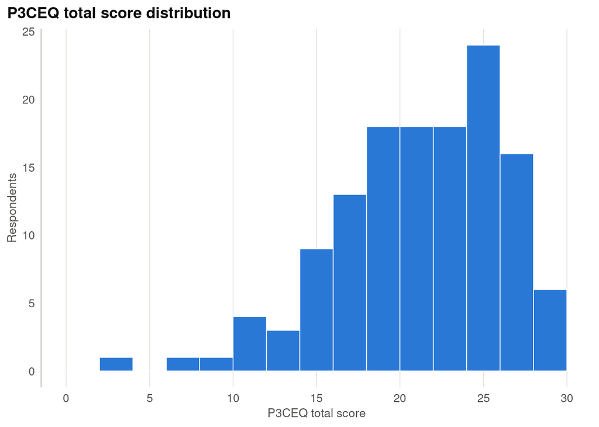

Figure 1: Distribution of P3CEQ total scores (0–30, higher = more person-centred)

```r
p3ceq |>
  filter(!is.na(total)) |>
  ggplot(aes(total)) +
  geom_histogram(binwidth = 2, boundary = 0, fill = pal_blue, colour = "white", linewidth = 0.3) +
  scale_x_continuous(limits = c(0, 30), breaks = seq(0, 30, 5)) +
  labs(x = "P3CEQ total score", y = "Respondents", title = "P3CEQ total score distribution")
```

### 3.2 Care coordination subscale vs PaRIS 2023

cohealth Kensington general practice previously conducted the P3CEQ survey in 2023 as part of PaRIS (ACSQHC, 2025). 193 patients aged 45+ years of the cohealth Kensington clinic returned a PaRIS survey.

PaRIS reported the P3CEQ care coordination (CC) subscale breakdown, comparing Kensington’s own patients against a national comparison group (see `P3CEQ coordinated care subscale PaRIS 2023.png`).

```r
cc_bands <- c("Very low (0–3)", "Low (3.01–6)", "Moderate (6.01–9)", "High (9.01–12)", "Very high (12.01–15)")

# Reference percentages read off "P3CEQ coordinated care subscale PaRIS 2023.png" - no digital
# source for these exists, only that chart image (Kensington's 2023 PaRIS results and the PaRIS
# national comparison group). Average scores from the same image: 8.8 (Kensington 2023, Moderate)
# and 9.8 (PaRIS comparison 2023).
cc_paris_2023 <- tibble(
  band = factor(cc_bands, levels = cc_bands),
  `Kensington 2023`        = c(10, 19, 24, 23, 24),
  `PaRIS comparison 2023`  = c(6, 14, 24, 33, 23)
)

band_of_cc <- function(x) cut(x, breaks = c(0, 3, 6, 9, 12, 15), labels = cc_bands, include.lowest = TRUE)

cc_2026_data <- p3ceq |>
  left_join(survey |> select(KEY, q26), by = "KEY") |>
  filter(q26 %in% c(3, 4), !is.na(cc_subscale)) # age 45-64 (3) or 65+ (4), per q26opts

cc_2026_bands <- cc_2026_data |>
  mutate(band = band_of_cc(cc_subscale)) |>
  count(band, .drop = FALSE) |>
  mutate(`Kensington 2026` = n / sum(n) * 100) |>
  select(band, `Kensington 2026`)

cc_compare <- cc_paris_2023 |>
  left_join(cc_2026_bands, by = "band") |>
  pivot_longer(-band, names_to = "series", values_to = "pct") |>
  mutate(series = factor(series, levels = c("Kensington 2023", "PaRIS comparison 2023", "Kensington 2026")))
```

```r
avg_cc_2026 <- mean(cc_2026_data$cc_subscale)
n_cc_2026   <- nrow(cc_2026_data)
```

Average P3CEQ care coordination subscale score among respondents aged 45+ (n = 103) was **10.3** (High (9.01–12)) for Kensington 2026. This compares to 8.8 (Moderate) for Kensington 2023 and 9.8 for the PaRIS 2023 comparison group.

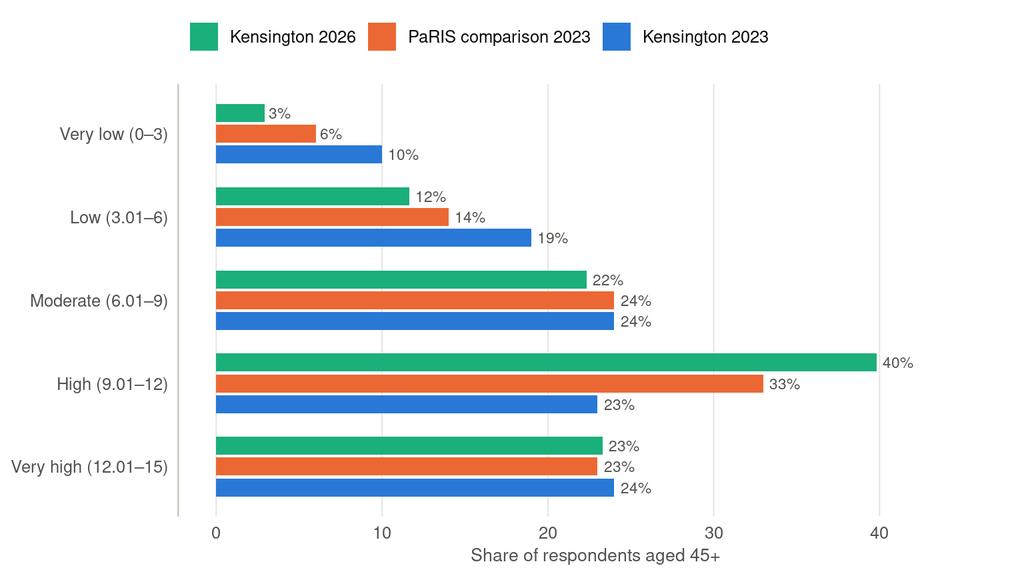

Figure 2: P3CEQ care coordination subscale (0–15), patients aged 45+: Kensington 2026 vs PaRIS 2023

```r
ggplot(cc_compare, aes(pct, fct_rev(band), fill = series)) +
  geom_col(position = position_dodge(width = 0.75), width = 0.65) +
  geom_text(aes(label = paste0(round(pct), "%")), position = position_dodge(width = 0.75),
            hjust = -0.2, size = 3, colour = ink_secondary) +
  scale_fill_manual(values = pal_cat[1:3]) +
  scale_x_continuous(limits = c(0, max(cc_compare$pct, na.rm = TRUE) * 1.15)) +
  labs(x = "Share of respondents aged 45+", y = NULL) +
  # legend reads top-down as Kensington 2026 / PaRIS comparison 2023 / Kensington 2023, matching
  # the dodge order of the bars themselves (series factor levels stay as-is - this only reorders
  # the legend keys, not the fill scale or bar positions)
  guides(fill = guide_legend(reverse = TRUE))
```

### 3.3 Confidence to self-manage and person-centred care vs PaRIS10 Dashboard 2024

The OECD’s PaRIS10 Dashboard (OECD 2025) benchmarks two further P3CEQ-derived measures for primary care users aged 45+ living with one or more chronic conditions: **confidence to self-manage** (a single item — “how confident are you that you can manage your own health and well-being?” — positive if confident/very confident) and **person-centred care** (the PC subscale above, out of 24, positive if the score is 12 or more).

The Australia and OECD PaRIS figures below are age-sex standardised to the OECD PaRIS standard population (OECD 2025; Groenewegen et al. 2024); Kensington’s figures are standardised to the same reference population (see Notes).

```r
paris10_data <- p3ceq |>
  left_join(
    survey |>
      mutate(
        KEY, q22, q26,
        n_conditions = rowSums(across(matches("^q9_(1|2|3|4|5|6|7|8|9|10|11|12)$")), na.rm = TRUE),
        .keep = "none"
      ),
    by = "KEY"
  ) |>
  filter(q26 %in% c(3, 4), n_conditions >= 1) # age 45+ (per q26opts) with 1+ long-term condition

n_paris10          <- nrow(paris10_data)
n_paris10_nogender <- sum(is.na(paris10_data$q22)) # unanswered Q22 - excluded below, no stratum to assign

# ---- age-sex standardisation to the OECD PaRIS standard population -------------------------
# Table 7.5 of @oecd-paris (Section 7.7.2) gives the OECD-PaRIS standard population as two
# marginal distributions, not a joint age-by-sex table: age in four bands (45-54 25%, 55-64 28%,
# 65-74 27%, 75+ 20%) and sex (women 55%, men 45%). Kensington's q26 only distinguishes 45-64 vs
# 65+, so those OECD age bands are collapsed to match (45-64 -> 53%, 65+ -> 47%) and combined with
# sex assuming independence (the OECD report doesn't publish the cross-tabulation) into four
# stratum weights, used to directly reweight Kensington's own stratum estimates - the saturated
# special case of the re-centred-regression method in the PaRIS data analysis plan
# [@groenewegen2024].
oecd_std_weights <- tribble(
  ~q26, ~q22, ~std_weight,
  3,    1,    0.53 * 0.45, # 45-64, Male
  3,    2,    0.53 * 0.55, # 45-64, Female
  4,    1,    0.47 * 0.45, # 65+, Male
  4,    2,    0.47 * 0.55  # 65+, Female
)

paris10_strata <- paris10_data |>
  filter(!is.na(q22)) |>
  group_by(q26, q22) |>
  summarise(
    n          = n(),
    pct_conf   = mean(p10 >= 2, na.rm = TRUE) * 100, # p10 = recoded q19; 2="Confident", 3="Very confident"
    pct_pc_pos = mean(pc_subscale >= 12, na.rm = TRUE) * 100,
    avg_pc     = mean(pc_subscale, na.rm = TRUE),
    .groups = "drop"
  ) |>
  left_join(oecd_std_weights, by = c("q26", "q22"))

standardise <- function(x) weighted.mean(x, paris10_strata$std_weight)

pct_conf_2026_std   <- standardise(paris10_strata$pct_conf)
pct_pc_pos_2026_std <- standardise(paris10_strata$pct_pc_pos)
avg_pc_2026_std     <- standardise(paris10_strata$avg_pc)

# Crude (unstandardised) figures, kept for reference alongside the standardised ones above.
avg_pc_2026     <- mean(paris10_data$pc_subscale, na.rm = TRUE)
pct_pc_pos_2026 <- mean(paris10_data$pc_subscale >= 12, na.rm = TRUE) * 100
pct_conf_2026   <- mean(paris10_data$p10 >= 2, na.rm = TRUE) * 100

# Australia and OECD PaRIS figures are read directly off "PaRIS OECD PaRIS10 Dashboard.png"
# (Table 2.2, OECD "Does Healthcare Deliver?" report [@oecd-paris]) - the % reporting a positive
# outcome for each measure, among primary care users aged 45+ with 1+ chronic condition, age-sex
# standardised to the OECD PaRIS standard population; Kensington's figures below are standardised
# the same way (see above).
paris10_compare <- tribble(
  ~measure,                    ~series,                   ~pct,
  "Confidence to self-manage", "Kensington 2026",         pct_conf_2026_std,
  "Confidence to self-manage", "Australia (PaRIS 2024)",  61,
  "Confidence to self-manage", "OECD PaRIS (2024)",       59,
  "Person-centred care",       "Kensington 2026",         pct_pc_pos_2026_std,
  "Person-centred care",       "Australia (PaRIS 2024)",  93,
  "Person-centred care",       "OECD PaRIS (2024)",       87
) |>
  mutate(
    series  = factor(series, levels = c("Kensington 2026", "Australia (PaRIS 2024)", "OECD PaRIS (2024)")),
    measure = factor(measure, levels = c("Confidence to self-manage", "Person-centred care"))
  )
```

Among respondents aged 45+ with a long-term condition (n = 98; 2 did not answer Q22 and are excluded from standardisation), age-sex standardised to the OECD PaRIS standard population:

- **Confidence to self-manage**: 57% reported being confident or very confident in managing their own health and well-being (57% unstandardised), compared with 61% for Australia and 59% for the OECD PaRIS average.
- **Person-centred care**: average PC subscale score 18.6 out of 24 (94% scoring 12 or more, i.e. a “positive” experience; unstandardised: 18.5, 95%), compared with 18.1 (93%) for Australia and 16.6 (87%) for the OECD PaRIS average.

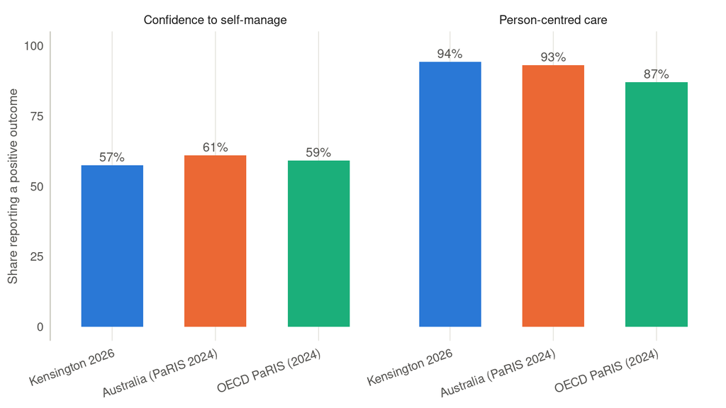

Figure 3: Confidence to self-manage and person-centred care vs PaRIS10 Dashboard 2024, patients aged 45+ with 1+ chronic condition (age-sex standardised)

```r
ggplot(paris10_compare, aes(series, pct, fill = series)) +
  geom_col(width = 0.6) +
  geom_text(aes(label = paste0(round(pct), "%")), vjust = -0.4, size = 3.5, colour = ink_secondary) +
  facet_wrap(~measure) +
  scale_fill_manual(values = pal_cat[1:3]) +
  scale_y_continuous(limits = c(0, 100)) +
  labs(x = NULL, y = "Share reporting a positive outcome") +
  theme(legend.position = "none",
        axis.text.x = element_text(angle = 20, hjust = 1))
```

### 3.4 Item-level results

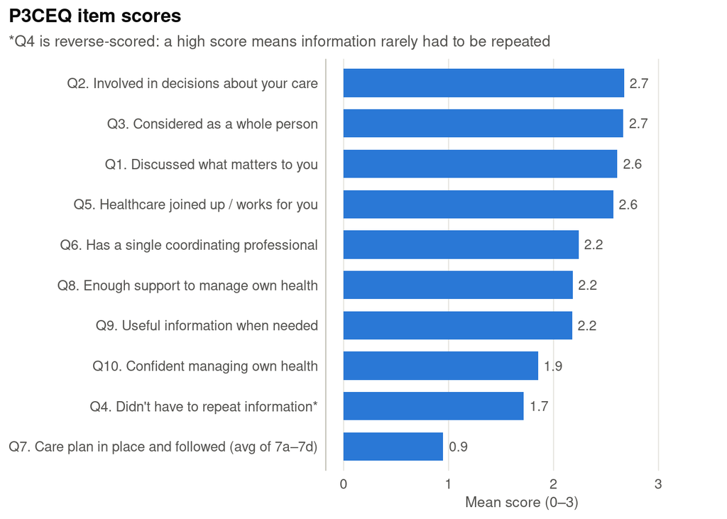

Figure 4: Mean score per P3CEQ item (0–3 scale, higher = better)

```r
p3ceq_item_labels <- c(
  p1  = "Q1. Discussed what matters to you",
  p2  = "Q2. Involved in decisions about your care",
  p3  = "Q3. Considered as a whole person",
  p4  = "Q4. Didn't have to repeat information*",
  p5  = "Q5. Healthcare joined up / works for you",
  p6  = "Q6. Has a single coordinating professional",
  p7  = "Q7. Care plan in place and followed (avg of 7a–7d)",
  p8  = "Q8. Enough support to manage own health",
  p9  = "Q9. Useful information when needed",
  p10 = "Q10. Confident managing own health"
)

p3ceq |>
  select(p1, p2, p3, p4, p5, p6, p7, p8, p9, p10) |>
  pivot_longer(everything(), names_to = "item", values_to = "score") |>
  filter(!is.na(score)) |>
  group_by(item) |>
  summarise(mean_score = mean(score), n = n(), .groups = "drop") |>
  mutate(item = fct_reorder(p3ceq_item_labels[item], mean_score)) |>
  ggplot(aes(mean_score, item)) +
  geom_col(fill = pal_blue, width = 0.7) +
  geom_text(aes(label = number(mean_score, accuracy = 0.1)),
            hjust = -0.3, size = 3.3, colour = ink_secondary) +
  scale_x_continuous(limits = c(0, 3.4), breaks = 0:3) +
  labs(x = "Mean score (0–3)", y = NULL,
       title = "P3CEQ item scores",
       subtitle = "*Q4 is reverse-scored: a high score means information rarely had to be repeated")
```

## 4 RACGP administrative staff, privacy and continuity of care

Questions 1–3 are selected questions from the (RACGP 2023). The questions chosen focused on the communication and interpersonal skills of administrative staff, privacy and confidentiality and continuity of care, with a focus on care coordination. Each question is rated on a 5-point Poor–Excellent scale (with “N/A” and “Don’t know” excluded from the summaries below).

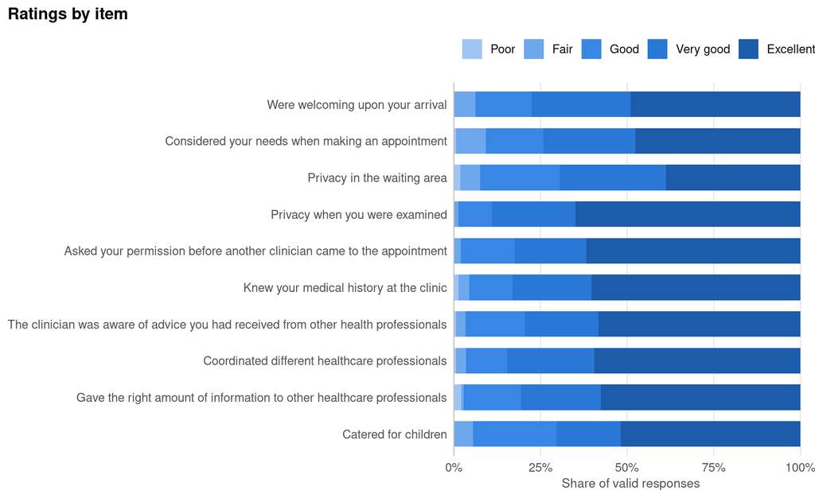

Figure 5: Reception, privacy and clinician coordination — response distribution (valid responses only)

```r
rate7_labs <- choice_labels("rate7")
rate7_valid <- names(rate7_labs)[!rate7_labs %in% c("N/A", "Don't know")]

rate7_vars <- c("q1a", "q1b", "q1c", "q2a", "q2b", "q2c", "q3a", "q3b", "q3c", "q3d")

rate7_long <- survey |>
  select(all_of(rate7_vars)) |>
  mutate(across(everything(), as.character)) |>
  pivot_longer(everything(), names_to = "var", values_to = "value") |>
  filter(value %in% rate7_valid) |>
  mutate(
    item = fct_rev(fct_inorder(map_chr(var, item_label))),
    response = factor(rate7_labs[value], levels = rate7_labs[rate7_valid])
  )

rate7_long |>
  count(item, response) |>
  group_by(item) |>
  mutate(pct = n / sum(n)) |>
  ungroup() |>
  ggplot(aes(pct, item, fill = response)) +
  geom_col(width = 0.7, position = position_stack(reverse = TRUE)) +
  scale_fill_manual(values = pal_seq) +
  scale_x_continuous(labels = percent, expand = expansion(mult = c(0, 0.02))) +
  labs(x = "Share of valid responses", y = NULL, title = "Ratings by item") +
  theme(legend.position = "top")
```

## 5 Long-term conditions

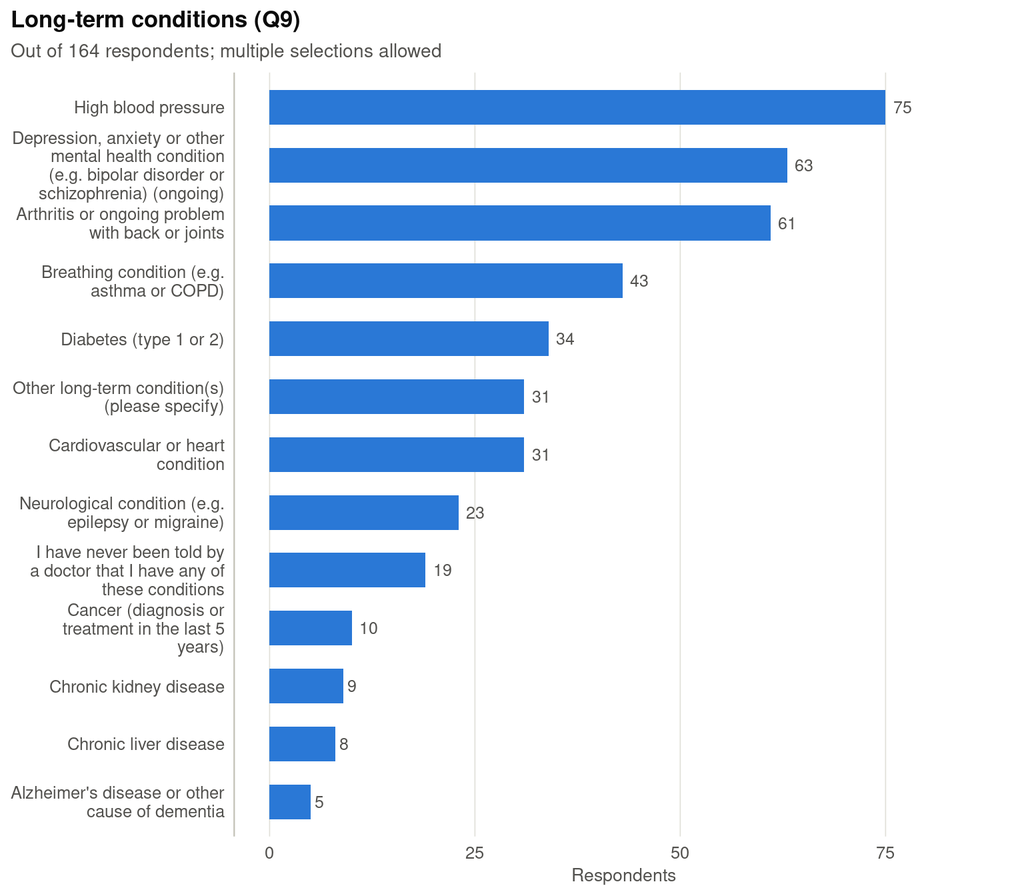

Figure 6: Long-term conditions reported by respondents

```r
summarise_multiselect <- function(data, prefix, list_name) {
  labs <- choice_labels(list_name)
  cols <- data |> select(matches(paste0("^", prefix, "_[0-9]+$")))
  tibble(
    value = str_remove(names(cols), paste0("^", prefix, "_")),
    n = colSums(cols, na.rm = TRUE)
  ) |>
    mutate(label = labs[value], pct = n / nrow(data)) |>
    arrange(desc(n))
}

# Unlike summarise_multiselect() above (one bar per option, so a respondent who selected several
# options is counted on several bars), this gives each respondent's full combination of selected
# options its own bar - needed for Q28, where holding more than one concession card is common and
# would otherwise be double-counted across the individual-card bars.
summarise_multiselect_combos <- function(data, prefix, list_name) {
  labs <- choice_labels(list_name)
  cols <- data |> select(matches(paste0("^", prefix, "_[0-9]+$")))
  values <- str_remove(names(cols), paste0("^", prefix, "_"))
  mat <- as.matrix(cols)
  mat[is.na(mat)] <- 0
  combo <- apply(mat, 1, function(row) {
    selected <- values[row == 1]
    if (length(selected) == 0) return(NA_character_) # skipped the question entirely
    paste(labs[selected], collapse = " + ")
  })
  tibble(label = combo) |>
    filter(!is.na(label)) |>
    count(label, name = "n") |>
    mutate(pct = n / nrow(data)) |>
    arrange(desc(n))
}

conditions <- summarise_multiselect(survey, "q9", "conditions")

conditions |>
  mutate(label = fct_reorder(str_wrap(label, 28), n)) |>
  ggplot(aes(n, label)) +
  geom_col(fill = pal_blue, width = 0.6) +
  geom_text(aes(label = n), hjust = -0.4, size = 3.3, colour = ink_secondary) +
  scale_x_continuous(limits = c(0, max(conditions$n) * 1.15)) +
  labs(x = "Respondents", y = NULL, title = "Long-term conditions (Q9)",
       subtitle = paste0("Out of ", n_consented, " respondents; multiple selections allowed"))
```

Q9 lets respondents specify “Other long-term condition(s)” as free text. `q9_other` holds what respondents typed in; below are those responses as given, one row per respondent.

```r
other_conditions <- survey |>
  mutate(q9_other = str_squish(q9_other)) |>
  filter(!is.na(q9_other), q9_other != "") |>
  mutate(`Free-text response` = q9_other, .keep = "none")

kable(other_conditions, align = "l")
```

Table 1: Q9 “Other long-term condition(s)”: free-text responses

| Free-text response |
| --- |
| Cholesterol |
| Physical,mental.& medical permanent conditions |
| CMML,HIV,LIVER PROBLEMS, VASCULAR DISEASE, CONDITIONS ARISE ALMOST EVERY YEAR |
| Cerebellum ataxia |
| Thyroid under active. Gastro intestinal problems |
| Blood vessel disease |
| Chronic back pain, insomnia, post traumatic stress disorder, high cholesterol |
| C.I.D.P Diviticulist heart dease arthritis |
| Monitoring prostate |
| Chronic bowel issues. |
| Chronic pain |
| Heart Failure. |
| I don’t know how to write it in english |
| Chronic neck pain |
| Essential tremor, chronic back pain, asthma and pain below the hips. |
| Osteoporosis |
| Crohn’s disease |
| sorry I don’t know how to write it in English |
| eczema |
| Hepatitis B |
| osteoporosis |
| anxiety, depression, vertigo PHSD |
| emphasemia, panic attacks, renal impairment, P.T.S.D, heart issues |
| THYROID |
| Cancer 20 years ago |
| lymphoedema - leg |

26 free-text responses, out of 31 respondents who selected “Other long-term condition(s)”.

### 5.1 Multiple chronic conditions vs PaRIS 2025

The 2025 PaRIS Australian national report states that 64% of patients aged 45+ reported having at least one chronic condition (ACSQHC, 2025).

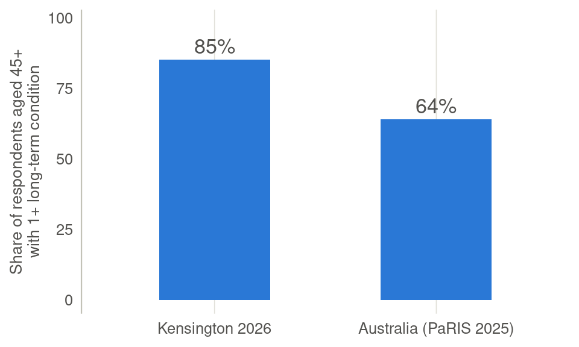

Figure 7: Any long-term condition, respondents aged 45+: Kensington 2026 vs PaRIS Australia 2025

```r
# Number of conditions = count of actual conditions ticked in Q9 (q9_1..q9_12), excluding the
# "I have never been told..." option (q9_13, not a condition).
num_conditions <- survey |>
  mutate(
    KEY,
    n_conditions = rowSums(across(matches("^q9_(1|2|3|4|5|6|7|8|9|10|11|12)$")), na.rm = TRUE),
    age_group = case_when(
      q26 %in% c(1, 2) ~ "under45",
      q26 %in% c(3, 4) ~ "45plus",
      TRUE             ~ "unspecified" # q26 == 5 ("Don't wish to say") or blank
    ),
    .keep = "none"
  )

n_45plus_total <- sum(num_conditions$age_group == "45plus")
n_45plus_any   <- sum(num_conditions$age_group == "45plus" & num_conditions$n_conditions >= 1)
pct_45plus_any <- n_45plus_any / n_45plus_total * 100

any_condition_compare <- tibble(
  series = factor(c("Kensington 2026", "Australia (PaRIS 2025)"),
                   levels = c("Kensington 2026", "Australia (PaRIS 2025)")),
  pct = c(pct_45plus_any, 64) # Australia figure quoted directly in "PaRIS 2025 Australia chronic conditions.png"
)

any_condition_compare |>
  ggplot(aes(series, pct)) +
  geom_col(fill = pal_blue, width = 0.5) +
  geom_text(aes(label = paste0(round(pct), "%")), vjust = -0.4, size = 4.5, colour = ink_secondary) +
  scale_y_continuous(limits = c(0, max(any_condition_compare$pct) * 1.15)) +
  labs(x = NULL, y = "Share of respondents aged 45+\nwith 1+ long-term condition")
```

In this survey, 98 of 115 respondents aged 45+ (85%) from cohealth Kensington report at least one long-term condition, vs. 64% in the PaRIS Australia 2025 report.

OECD (2025) describes the number of reported chronic conditions per patient, among patients aged 45+ report who report having at least one condition. Australian and OECD figures are compared below to survey respondents from cohealth Kensington 2026, split by age band.

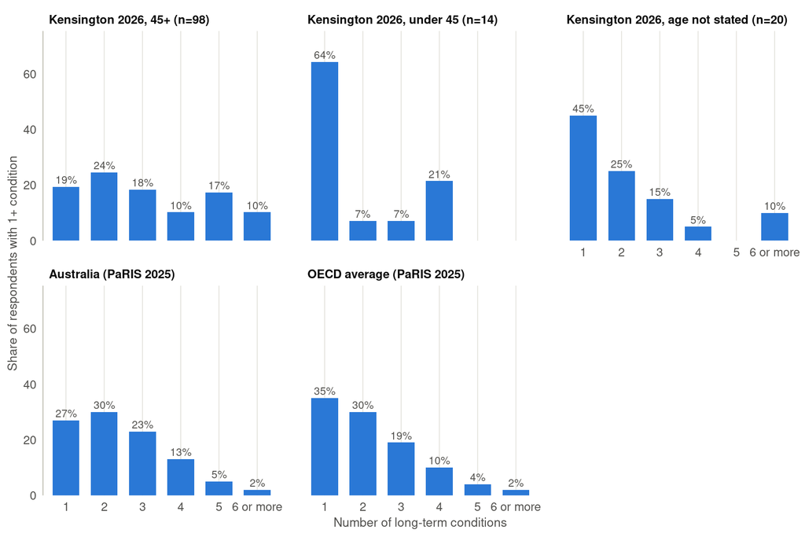

Figure 8: Number of long-term conditions, among respondents reporting at least one

```r
n_kensington <- num_conditions |>
  filter(n_conditions >= 1) |>
  count(age_group, name = "n_group")

kensington_dist <- num_conditions |>
  filter(n_conditions >= 1) |>
  mutate(n_conditions = pmin(n_conditions, 6)) |>
  count(age_group, n_conditions) |>
  left_join(n_kensington, by = "age_group") |>
  mutate(pct = n / n_group * 100) |>
  select(age_group, n_conditions, pct, n_group)

age_group_labels <- c(
  `45plus`      = paste0("Kensington 2026, 45+ (n=", n_kensington$n_group[n_kensington$age_group == "45plus"], ")"),
  under45       = paste0("Kensington 2026, under 45 (n=", n_kensington$n_group[n_kensington$age_group == "under45"], ")"),
  unspecified   = paste0("Kensington 2026, age not stated (n=", n_kensington$n_group[n_kensington$age_group == "unspecified"], ")")
)

kensington_long <- kensington_dist |>
  mutate(series = age_group_labels[age_group]) |>
  select(series, n_conditions, pct)

# Read off "PaRIS 2025 multiple chronic conditions.png" by measuring the stacked-bar segment
# widths for the Australia and OECD PaRIS rows (no digital source for the underlying values was
# available - the chart has no printed data labels) - approximate to the nearest whole percent.
paris_2025 <- tribble(
  ~series,                    ~n_conditions, ~pct,
  "Australia (PaRIS 2025)",   1,             27,
  "Australia (PaRIS 2025)",   2,             30,
  "Australia (PaRIS 2025)",   3,             23,
  "Australia (PaRIS 2025)",   4,             13,
  "Australia (PaRIS 2025)",   5,             5,
  "Australia (PaRIS 2025)",   6,             2,
  "OECD average (PaRIS 2025)",1,             35,
  "OECD average (PaRIS 2025)",2,             30,
  "OECD average (PaRIS 2025)",3,             19,
  "OECD average (PaRIS 2025)",4,             10,
  "OECD average (PaRIS 2025)",5,             4,
  "OECD average (PaRIS 2025)",6,             2
)

series_order <- c(age_group_labels[c("45plus", "under45", "unspecified")],
                   "Australia (PaRIS 2025)", "OECD average (PaRIS 2025)")

conditions_compare <- bind_rows(kensington_long, paris_2025) |>
  mutate(
    series = factor(series, levels = series_order),
    n_conditions = factor(n_conditions, levels = 1:6, labels = c("1", "2", "3", "4", "5", "6 or more"))
  )

conditions_compare |>
  ggplot(aes(n_conditions, pct)) +
  geom_col(fill = pal_blue, width = 0.7) +
  geom_text(aes(label = paste0(round(pct), "%")), vjust = -0.4, size = 3, colour = ink_secondary) +
  scale_y_continuous(limits = c(0, max(conditions_compare$pct, na.rm = TRUE) * 1.15),
                      expand = expansion(mult = c(0, 0.02))) +
  facet_wrap(~series, ncol = 3) +
  labs(x = "Number of long-term conditions", y = "Share of respondents with 1+ condition") +
  theme(strip.text = element_text(face = "bold", colour = ink_primary, hjust = 0),
        panel.spacing = unit(1.2, "lines"))
```

### 5.2 Most reported chronic conditions vs PaRIS 2025

ACSQHC (2025) compares the specific chronic conditions reported among Australia and OECD patients aged 45+ (and who report at least one chronic condition). These statistics are compared to Kensington respondents aged 45+ with 1+ condition (98 survey respondents).

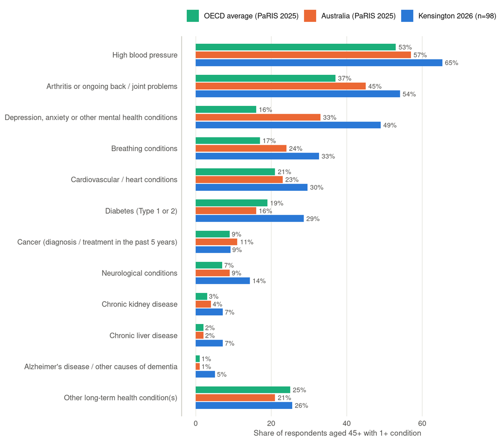

Figure 9: Most reported chronic conditions, respondents aged 45+ with 1+ condition: Kensington 2026 vs PaRIS 2025

```r
# Maps each Q9 "conditions" choice value to the matching row in the PaRIS Figure 1 chart, in that
# chart's own order (largest-to-smallest by the Australia figure).
condition_labels_paris <- c(
  `1`  = "High blood pressure",
  `4`  = "Arthritis or ongoing back / joint problems",
  `7`  = "Depression, anxiety or other mental health conditions",
  `5`  = "Breathing conditions",
  `2`  = "Cardiovascular / heart conditions",
  `3`  = "Diabetes (Type 1 or 2)",
  `11` = "Cancer (diagnosis / treatment in the past 5 years)",
  `8`  = "Neurological conditions",
  `9`  = "Chronic kidney disease",
  `10` = "Chronic liver disease",
  `6`  = "Alzheimer's disease / other causes of dementia",
  `12` = "Other long-term health condition(s)"
)
condition_order_paris <- unname(condition_labels_paris)

base_45plus_any <- num_conditions |> filter(age_group == "45plus", n_conditions >= 1) |> pull(KEY)

kensington_conditions_paris <- survey |>
  filter(KEY %in% base_45plus_any) |>
  select(all_of(paste0("q9_", names(condition_labels_paris)))) |>
  summarise(across(everything(), \(x) mean(x, na.rm = TRUE) * 100)) |>
  pivot_longer(everything(), names_to = "value", values_to = "pct") |>
  mutate(
    value = str_remove(value, "^q9_"),
    label = condition_labels_paris[value],
    series = paste0("Kensington 2026 (n=", length(base_45plus_any), ")")
  ) |>
  select(label, series, pct)

# Percentages printed directly on the bars in "PaRIS 2025 Australia chronic conditions.png" -
# read exactly from the chart, not estimated.
conditions_paris_2025 <- tribble(
  ~label,                                                    ~series,                     ~pct,
  "High blood pressure",                                     "Australia (PaRIS 2025)",    57,
  "High blood pressure",                                     "OECD average (PaRIS 2025)", 53,
  "Arthritis or ongoing back / joint problems",               "Australia (PaRIS 2025)",    45,
  "Arthritis or ongoing back / joint problems",               "OECD average (PaRIS 2025)", 37,
  "Depression, anxiety or other mental health conditions",    "Australia (PaRIS 2025)",    33,
  "Depression, anxiety or other mental health conditions",    "OECD average (PaRIS 2025)", 16,
  "Breathing conditions",                                     "Australia (PaRIS 2025)",    24,
  "Breathing conditions",                                     "OECD average (PaRIS 2025)", 17,
  "Cardiovascular / heart conditions",                        "Australia (PaRIS 2025)",    23,
  "Cardiovascular / heart conditions",                        "OECD average (PaRIS 2025)", 21,
  "Diabetes (Type 1 or 2)",                                   "Australia (PaRIS 2025)",    16,
  "Diabetes (Type 1 or 2)",                                   "OECD average (PaRIS 2025)", 19,
  "Cancer (diagnosis / treatment in the past 5 years)",       "Australia (PaRIS 2025)",    11,
  "Cancer (diagnosis / treatment in the past 5 years)",       "OECD average (PaRIS 2025)", 9,
  "Neurological conditions",                                  "Australia (PaRIS 2025)",    9,
  "Neurological conditions",                                  "OECD average (PaRIS 2025)", 7,
  "Chronic kidney disease",                                   "Australia (PaRIS 2025)",    4,
  "Chronic kidney disease",                                   "OECD average (PaRIS 2025)", 3,
  "Chronic liver disease",                                    "Australia (PaRIS 2025)",    2,
  "Chronic liver disease",                                    "OECD average (PaRIS 2025)", 2,
  "Alzheimer's disease / other causes of dementia",           "Australia (PaRIS 2025)",    1,
  "Alzheimer's disease / other causes of dementia",           "OECD average (PaRIS 2025)", 1,
  "Other long-term health condition(s)",                      "Australia (PaRIS 2025)",    21,
  "Other long-term health condition(s)",                      "OECD average (PaRIS 2025)", 25
)

conditions_paris_series <- c(unique(kensington_conditions_paris$series),
                              "Australia (PaRIS 2025)", "OECD average (PaRIS 2025)")

conditions_paris_compare <- bind_rows(kensington_conditions_paris, conditions_paris_2025) |>
  mutate(
    label = factor(label, levels = rev(condition_order_paris)),
    series = factor(series, levels = conditions_paris_series)
  )

ggplot(conditions_paris_compare, aes(pct, label, fill = series)) +
  geom_col(position = position_dodge(width = 0.75), width = 0.65) +
  geom_text(aes(label = paste0(round(pct), "%")), position = position_dodge(width = 0.75),
            hjust = -0.2, size = 3, colour = ink_secondary) +
  scale_fill_manual(values = pal_cat[1:3]) +
  scale_x_continuous(limits = c(0, max(conditions_paris_compare$pct, na.rm = TRUE) * 1.15)) +
  labs(x = "Share of respondents aged 45+ with 1+ condition", y = NULL) +
  # legend reads top-down as OECD, Australia, Kensington 2026, matching
  # the dodge order of the bars themselves (series factor levels stay as-is - this only reorders
  # the legend keys, not the fill scale or bar positions)
  guides(fill = guide_legend(reverse = TRUE))
```

### 5.3 Care coordination by number of conditions

#### 5.3.1 P3CEQ subscales

The chart below is restricted to respondents who answered Q9 (so “0” is a real answer of no long-term conditions, not a skipped question), with no age restriction. Unlike the 45+ comparisons against PaRIS benchmarks earlier, every respondent who answered Q9 is included regardless of age. The chart compares the P3CEQ person-centred (PC, out of 24) and care coordination (CC, out of 15) subscale scores against the number of long-term conditions reported.

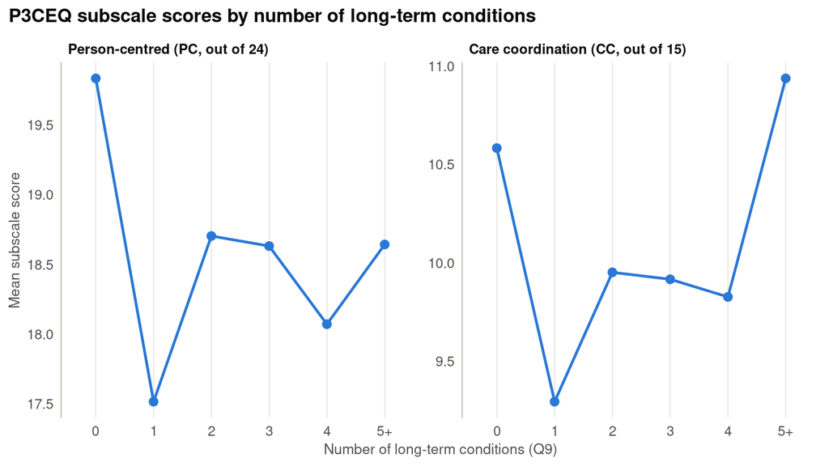

P3CEQ PC and CC subscale scores by number of long-term conditions (Q9)

```r
# The exploded q9_* indicator columns are 0 (not NA) even when Q9 was skipped entirely - SurveyCTO
# fills them in regardless - so "answered" has to be read off the raw q9 column (a space-separated
# list of selected codes, empty string when skipped) rather than off the indicator columns. A
# respondent who answered and selected only "never been told by a doctor..." (q9_13) is a real
# answer of zero conditions; one who left q9 blank is not and must be excluded, not counted as zero.
q9_conditions <- survey |>
  mutate(
    KEY,
    answered_q9 = !is.na(q9) & q9 != "",
    n_conditions = rowSums(across(matches("^q9_(1|2|3|4|5|6|7|8|9|10|11|12)$")), na.rm = TRUE),
    condition_band = factor(pmin(n_conditions, 5), levels = 0:5,
                             labels = c("0", "1", "2", "3", "4", "5+")),
    .keep = "none"
  ) |>
  filter(answered_q9)

subscale_labels <- c(
  pc_subscale = "Person-centred (PC, out of 24)",
  cc_subscale = "Care coordination (CC, out of 15)"
)

# PC and CC are on different maximum scores (24 vs 15), so they're faceted with independent y-axes
# rather than drawn as two lines on one shared axis.
subscale_by_conditions <- p3ceq |>
  select(KEY, pc_subscale, cc_subscale) |>
  inner_join(q9_conditions, by = "KEY") |>
  pivot_longer(c(pc_subscale, cc_subscale), names_to = "subscale", values_to = "score") |>
  filter(!is.na(score)) |>
  mutate(subscale = factor(subscale_labels[subscale], levels = subscale_labels))

subscale_summary <- subscale_by_conditions |>
  group_by(condition_band, subscale) |>
  summarise(mean_score = mean(score), n = n(), .groups = "drop")

ggplot(subscale_summary, aes(condition_band, mean_score, group = subscale)) +
  geom_line(linewidth = 0.9, colour = pal_blue) +
  geom_point(size = 2.5, colour = pal_blue) +
  facet_wrap(~subscale, scales = "free_y") +
  labs(x = "Number of long-term conditions (Q9)", y = "Mean subscale score",
       title = "P3CEQ subscale scores by number of long-term conditions") +
  theme(strip.text = element_text(face = "bold", colour = ink_primary, hjust = 0))
```

#### 5.3.2 P3CEQ Q7: care planning

The chart below breaks P3CEQ Q7 into its four care planning sub-items and shows the response distribution against the number of long-term conditions reported. It is restricted to respondents who reported at least one long-term condition in Q9. Q7a (Q13 in the survey, “Do you have a care plan?”) was asked of everyone, but Q7b–Q7d (Q14–Q16) were asked only of respondents who said “Yes” to Q7a. Their bars therefore show proportions *among respondents with a care plan*.

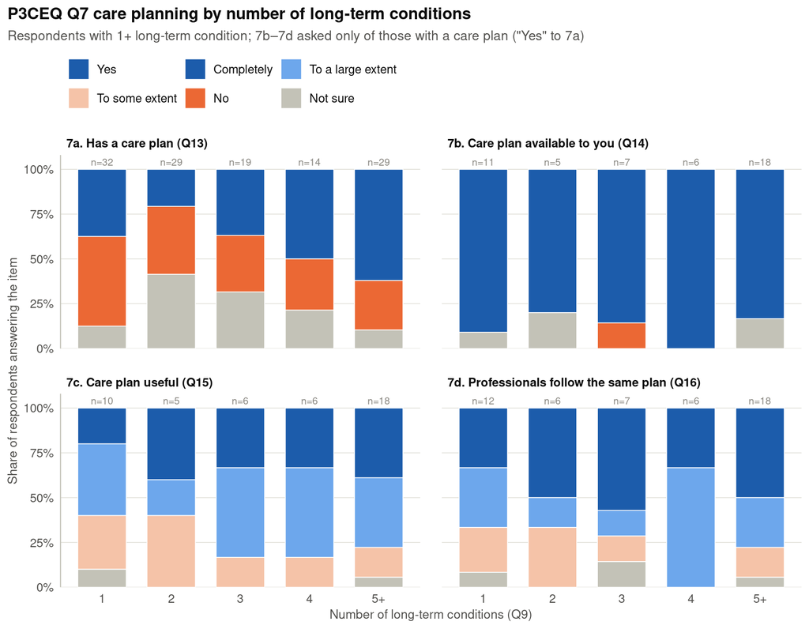

Figure 10: P3CEQ Q7 care planning sub-items (Q13–Q16) by number of long-term conditions (Q9), respondents with 1+ condition

```r
q7_vars <- c(q13 = "q13opts", q14 = "q14opts", q15 = "extent5", q16 = "extent5")

q7_item_labels <- c(
  q13 = "7a. Has a care plan (Q13)",
  q14 = "7b. Care plan available to you (Q14)",
  q15 = "7c. Care plan useful (Q15)",
  q16 = "7d. Professionals follow the same plan (Q16)"
)

# One fill scale covers both the Yes/No/Not sure lists (q13opts, q14opts) and the extent5 list.
# Levels run from most positive to most negative, then "Not sure", so position_fill stacks the
# positive answers at the top of each bar. P3CEQ scores "Not sure" as 0, the same as a negative
# answer, but it's shown in grey here so it can be told apart from an explicit "No"/"Not at all".
q7_response_levels <- c("Yes", "Completely", "To a large extent", "To some extent",
                        "No", "Not at all", "Not sure")
q7_response_colours <- c(
  "Yes"               = "#1c5cab",
  "Completely"        = "#1c5cab",
  "To a large extent" = "#6da7ec",
  "To some extent"    = "#f5c3a8",
  "No"                = "#eb6834",
  "Not at all"        = "#eb6834",
  "Not sure"          = "#c3c2b7"
)

q7_by_conditions <- survey |>
  select(KEY, all_of(names(q7_vars))) |>
  inner_join(q9_conditions, by = "KEY") |>
  filter(n_conditions >= 1) |> # only respondents reporting 1+ long-term condition
  mutate(condition_band = fct_drop(condition_band, only = "0")) |>
  pivot_longer(all_of(names(q7_vars)), names_to = "item", values_to = "value") |>
  filter(!is.na(value)) |> # skipped by SurveyCTO relevance (q14-q16 when q13 != Yes)
  mutate(
    response = map2_chr(item, as.character(value), \(i, v) choice_labels(q7_vars[[i]])[[v]]),
    response = factor(response, levels = q7_response_levels),
    item = factor(q7_item_labels[item], levels = q7_item_labels)
  )

q7_summary <- q7_by_conditions |>
  count(item, condition_band, response) |>
  group_by(item, condition_band) |>
  mutate(n_band = sum(n), pct = n / n_band * 100) |>
  ungroup()

q7_band_n <- q7_summary |> distinct(item, condition_band, n_band)

ggplot(q7_summary, aes(condition_band, pct, fill = response)) +
  geom_col(width = 0.7, colour = "white", linewidth = 0.3) +
  geom_text(data = q7_band_n, aes(condition_band, 100, label = paste0("n=", n_band)),
            inherit.aes = FALSE, vjust = -0.5, size = 2.8, colour = ink_muted) +
  # legend lists only the responses actually given ("Not at all" has had no takers so far, and an
  # unused level would otherwise show as an empty legend key)
  scale_fill_manual(values = q7_response_colours,
                    breaks = intersect(q7_response_levels, as.character(q7_summary$response))) +
  scale_y_continuous(limits = c(0, 108), breaks = seq(0, 100, 25),
                     labels = \(x) paste0(x, "%"), expand = expansion(mult = c(0, 0))) +
  facet_wrap(~item, ncol = 2) +
  labs(x = "Number of long-term conditions (Q9)", y = "Share of respondents answering the item",
       title = "P3CEQ Q7 care planning by number of long-term conditions",
       subtitle = "Respondents with 1+ long-term condition; 7b–7d asked only of those with a care plan (\"Yes\" to 7a)") +
  guides(fill = guide_legend(nrow = 2, byrow = TRUE)) +
  theme(strip.text = element_text(face = "bold", colour = ink_primary, hjust = 0),
        panel.grid.major.x = element_blank(),
        panel.grid.major.y = element_line(colour = grid_col, linewidth = 0.3),
        panel.spacing = unit(1.2, "lines"))
```

#### 5.3.3 RACGP care continuity and coordination questions

The same Q9-answered group is compared against the four care continuity and coordination items from the (RACGP patient feedback guide, 2023): “knew your medical history”, “the clinician was aware of advice you had received from other health professionals”, “coordinated different healthcare professionals” and “gave the right amount of information to other healthcare professionals”. As in Clinic-specific experience, “N/A” and “Don’t know” responses are excluded.

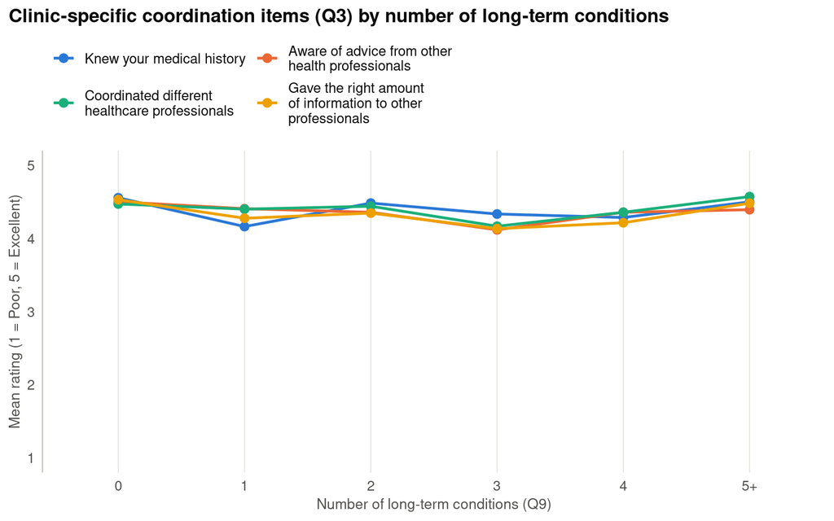

Q3 clinic-specific coordination items by number of long-term conditions (Q9)

```r
q3_vars <- c("q3a", "q3b", "q3c", "q3d")

q3_item_labels <- c(
  q3a = "Knew your medical history",
  q3b = "Aware of advice from other health professionals",
  q3c = "Coordinated different healthcare professionals",
  q3d = "Gave the right amount of information to other professionals"
)

q3_by_conditions <- survey |>
  select(KEY, all_of(q3_vars)) |>
  inner_join(q9_conditions, by = "KEY") |>
  mutate(across(all_of(q3_vars), ~ if_else(.x %in% 1:5, .x, NA_real_))) # drop N/A (6) / Don't know (7)

q3_summary <- q3_by_conditions |>
  select(condition_band, all_of(q3_vars)) |>
  pivot_longer(-condition_band, names_to = "item", values_to = "rating") |>
  filter(!is.na(rating)) |>
  group_by(condition_band, item) |>
  summarise(mean_rating = mean(rating), n = n(), .groups = "drop") |>
  mutate(item = factor(q3_item_labels[item], levels = q3_item_labels))

ggplot(q3_summary, aes(condition_band, mean_rating, colour = item, group = item)) +
  geom_line(linewidth = 0.9) +
  geom_point(size = 2.5) +
  scale_colour_manual(values = pal_cat[1:4], labels = \(x) str_wrap(x, 28)) +
  scale_y_continuous(limits = c(1, 5), breaks = 1:5) +
  labs(x = "Number of long-term conditions (Q9)", y = "Mean rating (1 = Poor, 5 = Excellent)",
       title = "Clinic-specific coordination items (Q3) by number of long-term conditions") +
  # four long labels don't fit on one legend row without running off the right edge of the
  # figure (only 3 of the 4 series were visible) - force two rows so all four are shown
  guides(colour = guide_legend(nrow = 2, byrow = TRUE))
```

## 6 Respondent profile

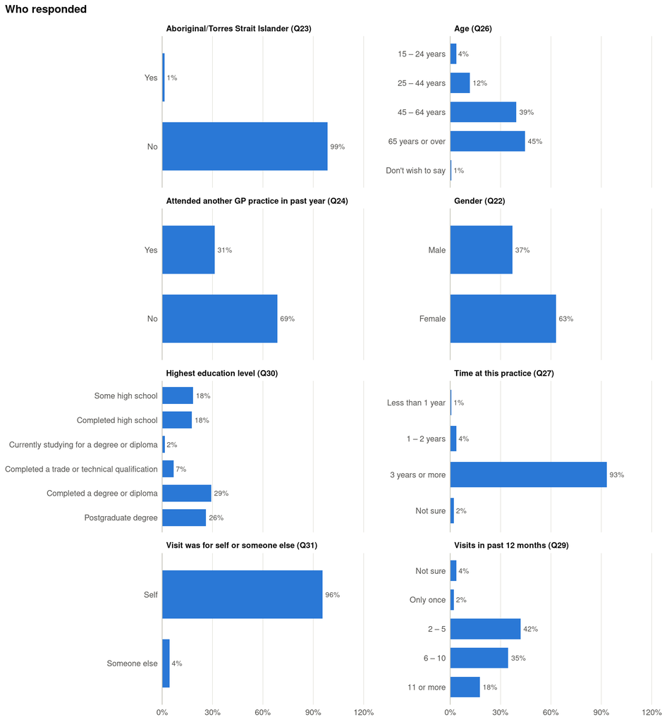

Figure 11: Respondent demographics

```r
demo_vars <- tribble(
  ~var, ~list, ~title,
  "q22", "q22opts", "Gender (Q22)",
  "q26", "q26opts", "Age (Q26)",
  "q27", "q27opts", "Time at this practice (Q27)",
  "q29", "q29opts", "Visits in past 12 months (Q29)",
  "q30", "q30opts", "Highest education level (Q30)",
  "q31", "q31opts", "Visit was for self or someone else (Q31)",
  "q23", "yesno",   "Aboriginal/Torres Strait Islander (Q23)",
  "q24", "yesno",   "Attended another GP practice in past year (Q24)"
)

demo_long <- pmap_dfr(demo_vars, function(var, list, title) {
  labs <- choice_labels(list)
  survey |>
    mutate(value = as.character(.data[[var]])) |>
    filter(!is.na(value), value %in% names(labs)) |>
    count(value) |>
    mutate(
      question = title,
      response = factor(labs[value], levels = labs),
      pct = n / sum(n)
    )
})

demo_long |>
  ggplot(aes(pct, fct_rev(response))) +
  geom_col(fill = pal_blue, width = 0.7) +
  geom_text(aes(label = percent(pct, accuracy = 1)), hjust = -0.2, size = 3, colour = ink_secondary) +
  scale_x_continuous(labels = percent, expand = expansion(mult = c(0, 0.25))) +
  facet_wrap(~question, scales = "free_y", ncol = 2) +
  labs(x = NULL, y = NULL, title = "Who responded") +
  theme(strip.text = element_text(face = "bold", colour = ink_primary, hjust = 0),
        panel.spacing.x = unit(1.4, "lines"))
```

```r
languages <- summarise_multiselect(survey, "q25", "languages")
# Combination-based, not per-card: several respondents hold more than one concession card (e.g.
# both a Health Care Card and a Pensioner Concession Card), so each held combination gets its own
# bar rather than counting that respondent once per card.
concession <- summarise_multiselect_combos(survey, "q28", "q28opts")
```

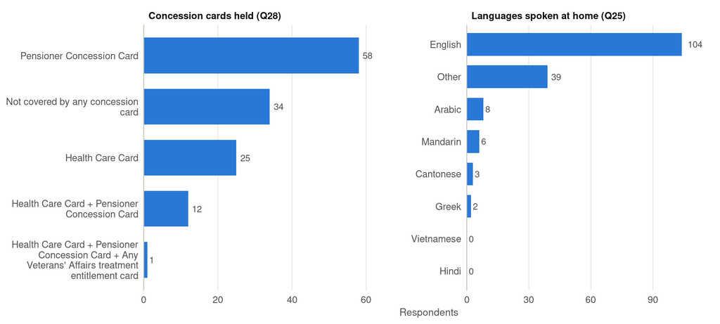

Figure 12: Languages spoken at home (Q25) and concession cards held (Q28, by combination held)

```r
bind_rows(
  languages |> mutate(facet = "Languages spoken at home (Q25)"),
  concession |> mutate(facet = "Concession cards held (Q28)")
) |>
  mutate(label = fct_reorder(str_wrap(label, 30), n)) |>
  ggplot(aes(n, label)) +
  geom_col(fill = pal_blue, width = 0.7) +
  geom_text(aes(label = n), hjust = -0.4, size = 3.2, colour = ink_secondary) +
  facet_wrap(~facet, scales = "free", ncol = 2) +
  scale_x_continuous(expand = expansion(mult = c(0, 0.15))) +
  labs(x = "Respondents", y = NULL) +
  theme(strip.text = element_text(face = "bold", colour = ink_primary, hjust = 0),
        panel.spacing.x = unit(1.4, "lines"))
```

Q25 “Other” responses come from a wide mix of languages. `q25_other` holds what respondents typed in; below are those free-text responses as given (grouped only where the text matches exactly), most-common first.

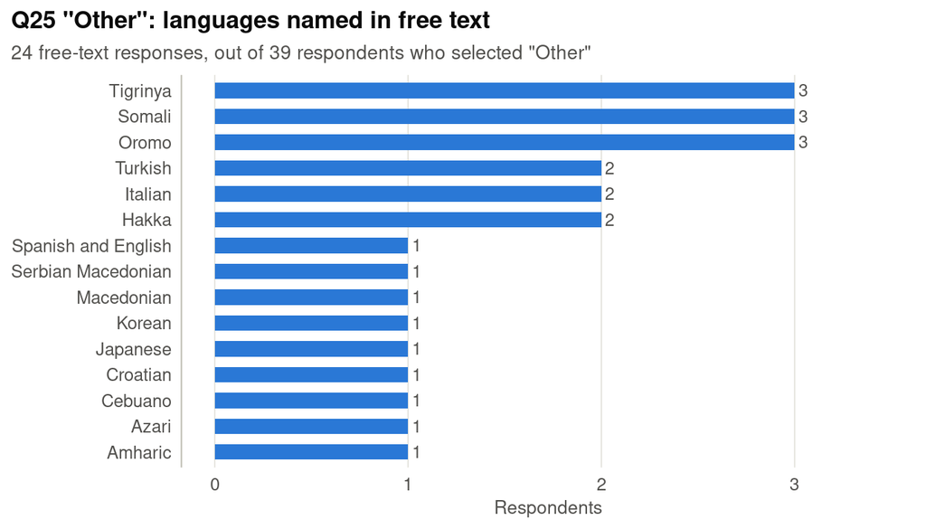

Figure 13: Q25 ‘Other’ responses: languages named in free text

```r
other_langs <- survey |>
  mutate(q25_other = str_squish(q25_other)) |>
  filter(!is.na(q25_other), q25_other != "") |>
  count(q25_other, sort = TRUE)

other_langs |>
  mutate(q25_other = fct_reorder(q25_other, n)) |>
  ggplot(aes(n, q25_other)) +
  geom_col(fill = pal_blue, width = 0.6) +
  geom_text(aes(label = n), hjust = -0.4, size = 3.3, colour = ink_secondary) +
  scale_x_continuous(limits = c(0, max(other_langs$n) * 1.15), breaks = scales::breaks_pretty()) +
  labs(x = "Respondents", y = NULL, title = "Q25 \"Other\": languages named in free text",
       subtitle = paste0(sum(other_langs$n), " free-text responses, out of ",
                          languages$n[languages$label == "Other"], " respondents who selected \"Other\""))
```

### 6.1 P3CEQ subscales by language spoken at home

The chart below is restricted to respondents who answered Q25 and who recorded at least one long-term condition in Q9 (per `q9_conditions` above, so a Q9 skip is excluded rather than counted as zero conditions), with no age restriction. Respondents are grouped into three categories based on the individual Q25 language options: “English only” (selected English, `q25_1`, and no other language), “Another language (no English)” (selected at least one other language and not English), and “English and another language” (selected both).

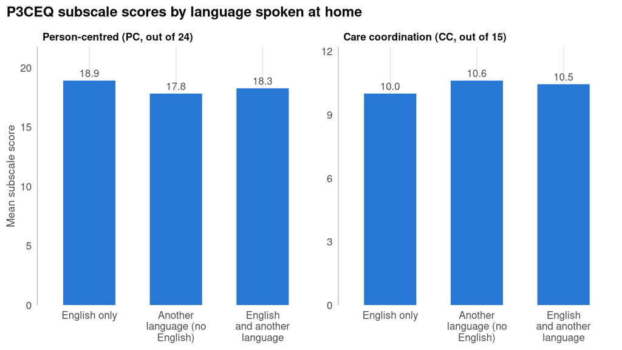

P3CEQ PC and CC subscale scores by language spoken at home (Q25), respondents with 1+ long-term conditions (Q9)

```r
language_group_levels <- c("English only", "Another language (no English)", "English and another language")

# The exploded q25_* indicator columns are 0 (not NA) even when Q25 was skipped entirely -
# SurveyCTO fills them in regardless - so "answered" has to be read off the raw q25 column (NA when
# skipped) rather than off the indicator columns. Once answered_q25 is TRUE, q25_1 is a real 0/1.
q25_language <- survey |>
  mutate(
    KEY,
    answered_q25 = !is.na(q25) & q25 != "",
    has_english  = q25_1 == 1,
    has_other    = rowSums(across(matches("^q25_[2-8]$")), na.rm = TRUE) > 0,
    language_group = factor(case_when(
      has_english & !has_other ~ "English only",
      !has_english & has_other ~ "Another language (no English)",
      has_english & has_other  ~ "English and another language"
    ), levels = language_group_levels),
    .keep = "none"
  ) |>
  filter(answered_q25)

# subscale_labels and q9_conditions defined earlier in "P3CEQ subscales by number of conditions"
# above; q9_conditions is already restricted to respondents who answered Q9.
subscale_by_language <- p3ceq |>
  select(KEY, pc_subscale, cc_subscale) |>
  inner_join(q25_language, by = "KEY") |>
  inner_join(q9_conditions |> select(KEY, n_conditions), by = "KEY") |>
  filter(n_conditions >= 1) |>
  pivot_longer(c(pc_subscale, cc_subscale), names_to = "subscale", values_to = "score") |>
  filter(!is.na(score)) |>
  mutate(subscale = factor(subscale_labels[subscale], levels = subscale_labels))

language_summary <- subscale_by_language |>
  group_by(language_group, subscale) |>
  summarise(mean_score = mean(score), n = n(), .groups = "drop")

ggplot(language_summary, aes(language_group, mean_score)) +
  geom_col(fill = pal_blue, width = 0.6) +
  geom_text(aes(label = number(mean_score, accuracy = 0.1)), vjust = -0.5, size = 3.3, colour = ink_secondary) +
  facet_wrap(~subscale, scales = "free_y") +
  scale_x_discrete(labels = \(x) str_wrap(x, 12)) +
  scale_y_continuous(expand = expansion(mult = c(0, 0.15))) +
  labs(x = NULL, y = "Mean subscale score",
       title = "P3CEQ subscale scores by language spoken at home") +
  theme(strip.text = element_text(face = "bold", colour = ink_primary, hjust = 0))
```

### 6.2 P3CEQ subscales by attendance at another general practice

The chart below is restricted to respondents who answered Q24 (“Have you been to another general practice in the last year?”) and who recorded at least one long-term condition in Q9 (per `q9_conditions` above, so a Q9 skip is excluded rather than counted as zero conditions), with no age restriction.

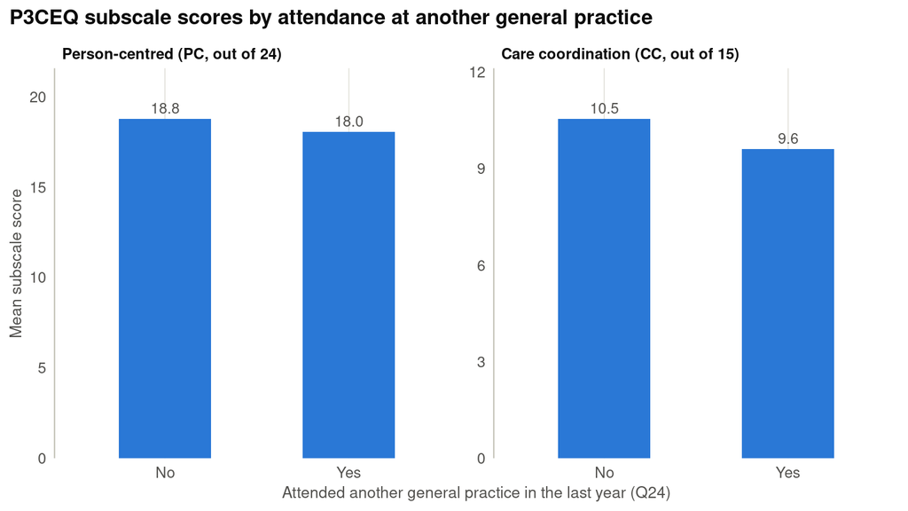

P3CEQ PC and CC subscale scores by attendance at another general practice in the last year (Q24), respondents with 1+ long-term conditions (Q9)

```r
q24_levels <- c("No", "Yes")

q24_attendance <- survey |>
  mutate(
    KEY,
    attended_other_gp = factor(case_when(q24 == 1 ~ "Yes", q24 == 2 ~ "No"), levels = q24_levels),
    .keep = "none"
  ) |>
  filter(!is.na(attended_other_gp))

# subscale_labels and q9_conditions defined earlier in "Care coordination by number of conditions"
# above; q9_conditions is already restricted to respondents who answered Q9.
subscale_by_q24 <- p3ceq |>
  select(KEY, pc_subscale, cc_subscale) |>
  inner_join(q24_attendance, by = "KEY") |>
  inner_join(q9_conditions |> select(KEY, n_conditions), by = "KEY") |>
  filter(n_conditions >= 1) |>
  pivot_longer(c(pc_subscale, cc_subscale), names_to = "subscale", values_to = "score") |>
  filter(!is.na(score)) |>
  mutate(subscale = factor(subscale_labels[subscale], levels = subscale_labels))

q24_summary <- subscale_by_q24 |>
  group_by(attended_other_gp, subscale) |>
  summarise(mean_score = mean(score), n = n(), .groups = "drop")

ggplot(q24_summary, aes(attended_other_gp, mean_score)) +
  geom_col(fill = pal_blue, width = 0.5) +
  geom_text(aes(label = number(mean_score, accuracy = 0.1)), vjust = -0.5, size = 3.3, colour = ink_secondary) +
  facet_wrap(~subscale, scales = "free_y") +
  scale_y_continuous(expand = expansion(mult = c(0, 0.15))) +
  labs(x = "Attended another general practice in the last year (Q24)", y = "Mean subscale score",
       title = "P3CEQ subscale scores by attendance at another general practice") +
  theme(strip.text = element_text(face = "bold", colour = ink_primary, hjust = 0))
```

### 6.3 Predictors of P3CEQ scores: language, gender, age and number of chronic conditions

Estimates through a multiple linear regression the association of language spoken at home (Q25), gender (Q22), age band (Q26) and number of long-term conditions (Q9, entered as a linear term, capped at 5+) with the P3CEQ total score and PC/CC subscales. The sample is restricted to respondents who recorded at least one long-term condition in Q9, and who answered Q25, Q22 and Q26. A “Don’t wish to say” age response (Q26 = 5) is treated as not having answered an age. Each outcome’s model uses every respondent in that sample with a non-missing score for it, so the total, PC and CC models can have slightly different sample sizes.

```r
# Age band collapses Q26's five options into three: "Don't wish to say" (5) and a blank answer are
# excluded (not an age), and the sparse 15-24 and 25-44 bands (2 and 11 respondents respectively,
# among those with 1+ condition) are combined into "Under 45" so the model isn't fit on near-empty
# cells.
demo_covariates <- survey |>
  mutate(
    KEY,
    gender = factor(case_when(q22 == 1 ~ "Male", q22 == 2 ~ "Female"), levels = c("Female", "Male")),
    age_band = factor(case_when(
      q26 %in% c(1, 2) ~ "Under 45",
      q26 == 3          ~ "45–64",
      q26 == 4          ~ "65+"
    ), levels = c("Under 45", "45–64", "65+")),
    .keep = "none"
  ) |>
  filter(!is.na(gender), !is.na(age_band))

# q25_language, q9_conditions defined earlier above; both are already
# restricted to respondents who answered Q25 / Q9 respectively. n_conditions is capped at 5
# here (matching condition_band's "5+" top band above) rather than left as the raw count, so the
# linear term isn't dominated by a handful of respondents reporting many more conditions
reg_data <- p3ceq |>
  select(KEY, total, pc_subscale, cc_subscale) |>
  inner_join(
    q9_conditions |> filter(n_conditions >= 1) |>
      mutate(n_conditions = pmin(n_conditions, 5)) |>
      select(KEY, n_conditions),
    by = "KEY"
  ) |>
  inner_join(q25_language |> select(KEY, language_group), by = "KEY") |>
  inner_join(demo_covariates, by = "KEY")

reg_outcome_labels <- c(
  total       = "P3CEQ total (0–30)",
  pc_subscale = "PC subscale (0–24)",
  cc_subscale = "CC subscale (0–15)"
)

# lm()'s default na.action (na.omit) drops rows missing that particular outcome, so each model
# fits on all of reg_data with a non-missing score for it - no separate per-outcome filter needed.
reg_predictors <- c("language_group", "gender", "age_band", "n_conditions")
reg_models <- map(names(reg_outcome_labels), function(outcome) {
  lm(reformulate(reg_predictors, response = outcome), data = reg_data)
}) |>
  set_names(names(reg_outcome_labels))

reg_term_labels <- c(
  "(Intercept)" = "Intercept (English only, Female, Under 45, 0 conditions)",
  "language_groupAnother language (no English)" = "Another language (no English)",
  "language_groupEnglish and another language"   = "English and another language",
  "genderMale"          = "Male",
  "age_band45–64"       = "45–64",
  "age_band65+"         = "65+",
  "n_conditions"        = "Number of conditions (Q9, per condition, capped at 5+)"
)

reg_coefs <- map_dfr(names(reg_models), function(nm) {
  broom::tidy(reg_models[[nm]], conf.int = TRUE) |>
    mutate(outcome = reg_outcome_labels[[nm]], n = nobs(reg_models[[nm]]))
}) |>
  mutate(
    outcome = factor(outcome, levels = reg_outcome_labels),
    term = factor(reg_term_labels[term], levels = rev(reg_term_labels))
  )
```

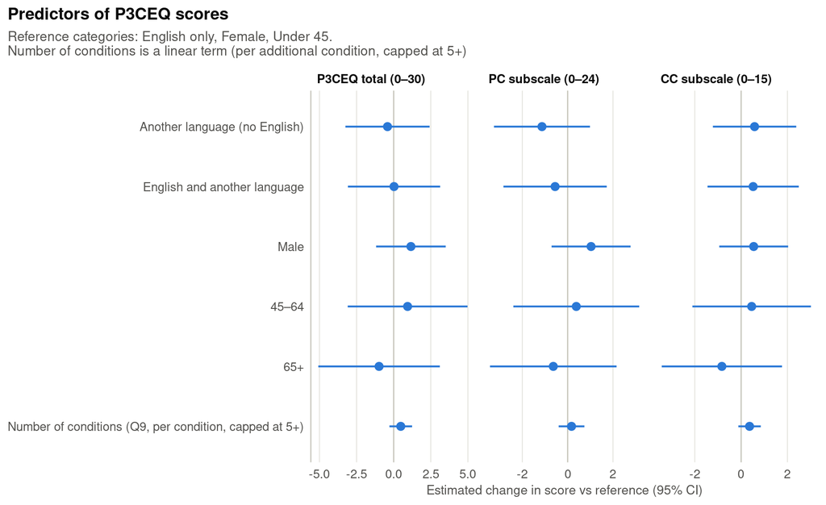

Figure 14: Predictors of P3CEQ scores: language, gender, age and number of conditions (95% CI), among respondents with 1+ long-term conditions (Q9)

```r
reg_coefs |>
  filter(term != "Intercept (English only, Female, Under 45, 0 conditions)") |>
  ggplot(aes(estimate, term)) +
  geom_vline(xintercept = 0, colour = baseline_col, linewidth = 0.4) +
  geom_pointrange(aes(xmin = conf.low, xmax = conf.high), colour = pal_blue, linewidth = 0.7, size = 0.5) +
  facet_wrap(~outcome, scales = "free_x") +
  labs(x = "Estimated change in score vs reference (95% CI)", y = NULL,
       title = "Predictors of P3CEQ scores",
       subtitle = "Reference categories: English only, Female, Under 45.\nNumber of conditions is a linear term (per additional condition, capped at 5+)") +
  theme(strip.text = element_text(face = "bold", colour = ink_primary, hjust = 0))
```

## References

Australian Commission on Safety and Quality in Health Care. 2025. “PaRIS Survey - Australian National Report 2025.” https://www.safetyandquality.gov.au/resources/paris-survey-australian-national-report-2025.

Burgers, J. S., G. E. Voerman, R. Grol, M. J. Faber, and E. C. Schneider. 2010. “Quality and Coordination of Care for Patients with Multiple Conditions: Results from an International Survey of Patient Experience.” *Evaluation & the Health Professions* 33 (3): 343–64. https://doi.org/10.1177/0163278710375695.

Grembowski, D., J. Schaefer, K. Johnson, et al. 2014. “A Conceptual Model of the Role of Complexity in the Care of Patients With Multiple Chronic Conditions.” *Medical Care* 52: S7–14. https://doi.org/10.1097/MLR.0000000000000045.

Groenewegen, Peter, Peter Spreeuwenberg, Rob Timans, et al. 2024. “Data Analysis Plan of the OECD PaRIS Survey: Leveraging a Multi-Level Approach to Analyse Data Collected from People Living with Chronic Conditions and Their Primary Care Practices in 20 Countries.” *BMC Research Notes* 17: 157. https://doi.org/10.1186/s13104-024-06815-7.

Lloyd, H., B. Fosh, B. Whalley, R. Byng, and J. Close. 2019. “Validation of the Person-Centred Coordinated Care Experience Questionnaire (P3CEQ).” *International Journal for Quality in Health Care* 31 (7): 506–12. https://doi.org/10.1093/intqhc/mzy212.

Maeng, D. D., G. R. Martsolf, D. P. Scanlon, and J. B. Christianson. 2012. “Care Coordination for the Chronically Ill: Understanding the Patient’s Perspective.” *Health Services Research* 47 (5): 1960–79. https://doi.org/10.1111/j.1475-6773.2012.01405.x.

OECD. 2025. *Does Healthcare Deliver?: Results from the Patient-Reported Indicator Surveys (PaRIS)*. OECD Publishing. https://doi.org/10.1787/c8af05a5-en.

RACGP. 2023. “Standards for General Practices (5th Edition), Patient Feedback Guide.” August. https://www.racgp.org.au/running-a-practice/practice-standards/standards-5th-edition/patient-feedback-guide.

University of Plymouth. 2017. “Person Centred Coordinated Experience Questionnaire P3C-EQ.” http://p3c.org.uk/prom-detail/29#ChildVerticalTab_11.

## 7 Notes

### 7.1 Age-sex standardisation

The Australia and OECD PaRIS figures in Confidence to self-manage and person-centred care vs PaRIS10 Dashboard 2024 are age-sex standardised. Each country’s raw estimate is reweighted to the *PaRIS standard population* — a reference age (four bands: 45–54, 55–64, 65–74, 75+) and sex (male/female) distribution for PaRIS-eligible patients aged 45+, built from the 17 participating OECD member countries’ own standard populations (OECD 2025, Table 7.5) — via a multilevel regression with re-centred age/sex predictors (Groenewegen et al. 2024), rather than each country’s raw sample composition.

To keep Kensington comparable, its figures in that section are age-sex standardised the same way. Respondents are split into the four age × sex strata that `q26` (45–64 / 65+) and `q22` (male/female) support, and each stratum’s estimate is reweighted to the OECD standard population’s age (collapsed to Kensington’s two age bands: 53% 45–64, 47% 65+) and sex (55% female, 45% male) shares, assumed independent of one another since the OECD report publishes only these two marginal distributions, not their cross-tabulation.

## 8 Appendices

**NoteP3CEQ PC and CC subscale scores by number of long-term conditions: sample sizes**

```r
subscale_summary |>
  arrange(subscale, condition_band) |>
  transmute(
    `Number of conditions` = condition_band,
    Subscale = subscale,
    `Mean score` = round(mean_score, 1),
    n
  ) |>
  kable(align = "llrr")
```

Table 2: P3CEQ PC and CC subscale scores by number of long-term conditions: underlying means and sample sizes

| Number of conditions | Subscale | Mean score | n |
| --- | --- | --- | --- |
| 0 | Person-centred (PC, out of 24) | 19.8 | 18 |
| 1 | Person-centred (PC, out of 24) | 17.5 | 31 |
| 2 | Person-centred (PC, out of 24) | 18.7 | 27 |
| 3 | Person-centred (PC, out of 24) | 18.6 | 19 |
| 4 | Person-centred (PC, out of 24) | 18.1 | 14 |
| 5+ | Person-centred (PC, out of 24) | 18.6 | 28 |
| 0 | Care coordination (CC, out of 15) | 10.6 | 18 |
| 1 | Care coordination (CC, out of 15) | 9.3 | 28 |
| 2 | Care coordination (CC, out of 15) | 10.0 | 26 |
| 3 | Care coordination (CC, out of 15) | 9.9 | 18 |
| 4 | Care coordination (CC, out of 15) | 9.8 | 13 |
| 5+ | Care coordination (CC, out of 15) | 10.9 | 28 |

**NoteP3CEQ Q7 care planning sub-items by number of long-term conditions: sample sizes**

```r
q7_summary |>
  mutate(cell = paste0(n, " (", round(pct), "%)")) |>
  select(item, condition_band, n_band, response, cell) |>
  pivot_wider(names_from = response, values_from = cell, values_fill = "–",
              names_sort = TRUE) |>
  arrange(item, condition_band) |>
  rename(Item = item, `Number of conditions` = condition_band, n = n_band) |>
  kable(align = "llr")
```

Table 3: P3CEQ Q7 care planning sub-items (Q13–Q16) by number of long-term conditions, respondents with 1+ condition: response counts

| Item | Number of conditions | n | Yes | Completely | To a large extent | To some extent | No | Not sure |
| --- | --- | --- | --- | --- | --- | --- | --- | --- |
| 7a. Has a care plan (Q13) | 1 | 32 | 12 (38%) | – | – | – | 16 (50%) | 4 (12%) |
| 7a. Has a care plan (Q13) | 2 | 29 | 6 (21%) | – | – | – | 11 (38%) | 12 (41%) |
| 7a. Has a care plan (Q13) | 3 | 19 | 7 (37%) | – | – | – | 6 (32%) | 6 (32%) |
| 7a. Has a care plan (Q13) | 4 | 14 | 7 (50%) | – | – | – | 4 (29%) | 3 (21%) |
| 7a. Has a care plan (Q13) | 5+ | 29 | 18 (62%) | – | – | – | 8 (28%) | 3 (10%) |
| 7b. Care plan available to you (Q14) | 1 | 11 | 10 (91%) | – | – | – | – | 1 (9%) |
| 7b. Care plan available to you (Q14) | 2 | 5 | 4 (80%) | – | – | – | – | 1 (20%) |
| 7b. Care plan available to you (Q14) | 3 | 7 | 6 (86%) | – | – | – | 1 (14%) | – |
| 7b. Care plan available to you (Q14) | 4 | 6 | 6 (100%) | – | – | – | – | – |
| 7b. Care plan available to you (Q14) | 5+ | 18 | 15 (83%) | – | – | – | – | 3 (17%) |
| 7c. Care plan useful (Q15) | 1 | 10 | – | 2 (20%) | 4 (40%) | 3 (30%) | – | 1 (10%) |
| 7c. Care plan useful (Q15) | 2 | 5 | – | 2 (40%) | 1 (20%) | 2 (40%) | – | – |
| 7c. Care plan useful (Q15) | 3 | 6 | – | 2 (33%) | 3 (50%) | 1 (17%) | – | – |
| 7c. Care plan useful (Q15) | 4 | 6 | – | 2 (33%) | 3 (50%) | 1 (17%) | – | – |
| 7c. Care plan useful (Q15) | 5+ | 18 | – | 7 (39%) | 7 (39%) | 3 (17%) | – | 1 (6%) |
| 7d. Professionals follow the same plan (Q16) | 1 | 12 | – | 4 (33%) | 4 (33%) | 3 (25%) | – | 1 (8%) |
| 7d. Professionals follow the same plan (Q16) | 2 | 6 | – | 3 (50%) | 1 (17%) | 2 (33%) | – | – |
| 7d. Professionals follow the same plan (Q16) | 3 | 7 | – | 4 (57%) | 1 (14%) | 1 (14%) | – | 1 (14%) |
| 7d. Professionals follow the same plan (Q16) | 4 | 6 | – | 2 (33%) | 4 (67%) | – | – | – |
| 7d. Professionals follow the same plan (Q16) | 5+ | 18 | – | 9 (50%) | 5 (28%) | 3 (17%) | – | 1 (6%) |

**NoteRACGP care continuity and coordination item by number of long-term conditions: sample sizes**

```r
q3_summary |>
  arrange(item, condition_band) |>
  transmute(
    `Number of conditions` = condition_band,
    Item = item,
    `Mean rating` = number(mean_rating, accuracy = 0.1),
    n
  ) |>
  kable(align = "llrr")
```

Table 4: Q3 RACGP care continuity and coordination items by number of long-term conditions: underlying means and sample sizes

| Number of conditions | Item | Mean rating | n |
| --- | --- | --- | --- |
| 0 | Knew your medical history | 4.6 | 18 |
| 1 | Knew your medical history | 4.2 | 37 |
| 2 | Knew your medical history | 4.5 | 29 |
| 3 | Knew your medical history | 4.3 | 21 |
| 4 | Knew your medical history | 4.3 | 14 |
| 5+ | Knew your medical history | 4.5 | 28 |
| 0 | Aware of advice from other health professionals | 4.5 | 16 |
| 1 | Aware of advice from other health professionals | 4.4 | 32 |
| 2 | Aware of advice from other health professionals | 4.4 | 28 |
| 3 | Aware of advice from other health professionals | 4.1 | 17 |
| 4 | Aware of advice from other health professionals | 4.4 | 14 |
| 5+ | Aware of advice from other health professionals | 4.4 | 28 |
| 0 | Coordinated different healthcare professionals | 4.5 | 17 |
| 1 | Coordinated different healthcare professionals | 4.4 | 30 |
| 2 | Coordinated different healthcare professionals | 4.4 | 25 |
| 3 | Coordinated different healthcare professionals | 4.2 | 18 |
| 4 | Coordinated different healthcare professionals | 4.4 | 14 |
| 5+ | Coordinated different healthcare professionals | 4.6 | 28 |
| 0 | Gave the right amount of information to other professionals | 4.5 | 17 |
| 1 | Gave the right amount of information to other professionals | 4.3 | 29 |
| 2 | Gave the right amount of information to other professionals | 4.3 | 26 |
| 3 | Gave the right amount of information to other professionals | 4.1 | 15 |
| 4 | Gave the right amount of information to other professionals | 4.2 | 14 |
| 5+ | Gave the right amount of information to other professionals | 4.5 | 27 |

**NoteP3CEQ PC and CC subscale scores by language: sample sizes**

```r
language_summary |>
  arrange(subscale, language_group) |>
  transmute(
    `Language spoken at home` = language_group,
    Subscale = subscale,
    `Mean score` = round(mean_score, 1),
    n
  ) |>
  kable(align = "llrr")
```

Table 5: P3CEQ PC and CC subscale scores by language spoken at home, respondents with 1+ long-term conditions: underlying means and sample sizes

| Language spoken at home | Subscale | Mean score | n |
| --- | --- | --- | --- |
| English only | Person-centred (PC, out of 24) | 18.9 | 61 |
| Another language (no English) | Person-centred (PC, out of 24) | 17.8 | 25 |
| English and another language | Person-centred (PC, out of 24) | 18.3 | 18 |
| English only | Care coordination (CC, out of 15) | 10.0 | 58 |
| Another language (no English) | Care coordination (CC, out of 15) | 10.6 | 24 |
| English and another language | Care coordination (CC, out of 15) | 10.5 | 16 |

**NoteP3CEQ PC and CC subscale scores by other GP attendance: sample sizes**

```r
q24_summary |>
  arrange(subscale, attended_other_gp) |>
  transmute(
    `Attended another GP practice (Q24)` = attended_other_gp,
    Subscale = subscale,
    `Mean score` = round(mean_score, 1),
    n
  ) |>
  kable(align = "llrr")
```

Table 6: P3CEQ PC and CC subscale scores by attendance at another general practice, respondents with 1+ long-term conditions: underlying means and sample sizes

| Attended another GP practice (Q24) | Subscale | Mean score | n |
| --- | --- | --- | --- |
| No | Person-centred (PC, out of 24) | 18.8 | 72 |
| Yes | Person-centred (PC, out of 24) | 18.0 | 31 |
| No | Care coordination (CC, out of 15) | 10.5 | 66 |
| Yes | Care coordination (CC, out of 15) | 9.6 | 30 |

**NotePredictors of P3CEQ scores: full regression output**

```r
reg_coefs |>
  arrange(outcome, term) |>
  transmute(
    Outcome = outcome,
    Term = term,
    n,
    Estimate = number(estimate, accuracy = 0.01),
    `95% CI` = paste0(number(conf.low, accuracy = 0.01), " to ", number(conf.high, accuracy = 0.01)),
    `p` = number(p.value, accuracy = 0.001)
  ) |>
  kable(align = "llrrrr")
```

Table 7: Predictors of P3CEQ scores: full coefficient table (language, gender, age, number of conditions)

| Outcome | Term | n | Estimate | 95% CI | p |
| --- | --- | --- | --- | --- | --- |
| P3CEQ total (0–30) | Number of conditions (Q9, per condition, capped at 5+) | 96 | 0.48 | -0.29 to 1.24 | 0.218 |
| P3CEQ total (0–30) | 65+ | 96 | -0.98 | -5.08 to 3.11 | 0.634 |
| P3CEQ total (0–30) | 45–64 | 96 | 0.94 | -3.10 to 4.97 | 0.646 |
| P3CEQ total (0–30) | Male | 96 | 1.16 | -1.18 to 3.51 | 0.328 |
| P3CEQ total (0–30) | English and another language | 96 | 0.02 | -3.09 to 3.13 | 0.988 |
| P3CEQ total (0–30) | Another language (no English) | 96 | -0.42 | -3.25 to 2.42 | 0.771 |
| P3CEQ total (0–30) | Intercept (English only, Female, Under 45, 0 conditions) | 96 | 20.03 | 15.78 to 24.29 | 0.000 |
| PC subscale (0–24) | Number of conditions (Q9, per condition, capped at 5+) | 102 | 0.17 | -0.40 to 0.74 | 0.552 |
| PC subscale (0–24) | 65+ | 102 | -0.63 | -3.42 to 2.16 | 0.653 |
| PC subscale (0–24) | 45–64 | 102 | 0.38 | -2.39 to 3.16 | 0.786 |
| PC subscale (0–24) | Male | 102 | 1.03 | -0.71 to 2.78 | 0.242 |
| PC subscale (0–24) | English and another language | 102 | -0.55 | -2.83 to 1.72 | 0.630 |
| PC subscale (0–24) | Another language (no English) | 102 | -1.13 | -3.25 to 0.98 | 0.291 |
| PC subscale (0–24) | Intercept (English only, Female, Under 45, 0 conditions) | 102 | 18.16 | 15.22 to 21.11 | 0.000 |
| CC subscale (0–15) | Number of conditions (Q9, per condition, capped at 5+) | 96 | 0.36 | -0.12 to 0.85 | 0.139 |
| CC subscale (0–15) | 65+ | 96 | -0.83 | -3.43 to 1.76 | 0.526 |
| CC subscale (0–15) | 45–64 | 96 | 0.45 | -2.10 to 3.01 | 0.725 |
| CC subscale (0–15) | Male | 96 | 0.54 | -0.94 to 2.03 | 0.470 |
| CC subscale (0–15) | English and another language | 96 | 0.52 | -1.45 to 2.49 | 0.602 |
| CC subscale (0–15) | Another language (no English) | 96 | 0.58 | -1.22 to 2.38 | 0.523 |
| CC subscale (0–15) | Intercept (English only, Female, Under 45, 0 conditions) | 96 | 8.94 | 6.25 to 11.64 | 0.000 |

```r
map_dfr(names(reg_models), function(nm) {
  broom::glance(reg_models[[nm]]) |>
    transmute(
      Outcome = reg_outcome_labels[[nm]],
      n = nobs(reg_models[[nm]]),
      `R²` = number(r.squared, accuracy = 0.01),
      `Adj. R²` = number(adj.r.squared, accuracy = 0.01),
      `F p-value` = number(p.value, accuracy = 0.001)
    )
}) |>
  kable(align = "lrrrr")
```

Table 8: Predictors of P3CEQ scores: model fit statistics

| Outcome | n | R² | Adj. R² | F p-value |
| --- | --- | --- | --- | --- |
| P3CEQ total (0–30) | 96 | 0.06 | 0.00 | 0.476 |
| PC subscale (0–24) | 102 | 0.05 | -0.01 | 0.542 |
| CC subscale (0–15) | 96 | 0.07 | 0.00 | 0.406 |